# PCAM ZC321-C3-CODE-BIRTHWEIGHTPREDICTION-G25

Predicting weight at birth based on US Birth data

### Course Title - PCAM ZC321

### Problem Statement

Low birth weight (LBW) of an infant can have serious health effects on it in its later life. World Health Organization defines Low birth weight (LBW) as a birth weight of an infant weighing 2,499 g or less. The birth weight of a baby is notable because very low birth weight babies are 100 times more likely to die compared to normal birth weight babies. We have to predict the weight of a baby

#### Import all required libraries

```python
#Importing all the necessary libraries

import pandas as pd
import numpy as np

# for plotting a graph
import matplotlib.pyplot as plt

# to tell jupyter to display graphs inline
%matplotlib inline

# to parse datimeobject
from dateutil.parser import parse

# for datetime operations
import datetime

# for missing value visulization
import missingno as msno

#For visualizations
import seaborn as sns
import matplotlib.pyplot as plt


# to find the outliers using DBSCAN and KNN algorithms
from sklearn.cluster import DBSCAN
from sklearn.neighbors import NearestNeighbors

from sklearn import metrics

#To display all columns
pd.set_option('display.max_columns', None)

#To perform encoding
from sklearn.preprocessing import LabelEncoder

#To perform scaling
from sklearn.preprocessing import MinMaxScaler

#To detect the outliers using zscore
from scipy.stats import zscore

#To perform PCA
from sklearn.decomposition import PCA

#To set the figure size
sns.set(rc={'figure.figsize':(10,5)})
import warnings
warnings.filterwarnings('ignore')

#!pip install dython --> #corelation for categorical attributes
from dython.nominal import associations

#To Build the Model
from sklearn.model_selection import train_test_split
from sklearn.preprocessing import StandardScaler
from sklearn.linear_model import LinearRegression
from sklearn.metrics import mean_squared_error, r2_score
import math
from sklearn.ensemble import RandomForestRegressor
from sklearn import metrics
```

#### Read Directory and get the file

```python
# Download the dataset to the working directory
# In this case the dataset is stored in below directory

#To execute the below python implementation, please change the path to the appropriate
#directory in the "path" variable to run the program:

#path = "C:\\Users\\user\\Documents\\CapstoneProject\\Data\\"
path=""
filename = "US_births(2018).csv"
file=path+filename


# display path
print(file)
```

```
US_births(2018).csv
```

#### Read datset

```python
# Read the data from csv from a panda function read_csv
# store the data in a data frame, call it birthdata

birthdata = pd.read_csv(file, low_memory=False)
```

# Data Overview

```python
# Review the top 5 rows to get a glimpse of the dataset

birthdata.head()
```

|  | ATTEND | BFACIL | BMI | CIG_0 | DBWT | DLMP_MM | DLMP_YY | DMAR | DOB_MM | DOB_TT | DOB_WK | DOB_YY | DWgt_R | FAGECOMB | FEDUC | FHISPX | FRACE15 | FRACE31 | FRACE6 | ILLB_R | ILOP_R | ILP_R | IMP_SEX | IP_GON | LD_INDL | MAGER | MAGE_IMPFLG | MAR_IMP | MBSTATE_REC | … |
| --- | --- | --- | --- | --- | --- | --- | --- | --- | --- | --- | --- | --- | --- | --- | --- | --- | --- | --- | --- | --- | --- | --- | --- | --- | --- | --- | --- | --- | --- | --- |
| 0 | 1 | 1 | 30.7 | 0 | 3657 | 4 | 2017 | 1 | 1 | 1227 | 2 | 2018 | 231 | 31 | 3 | 1 | 1 | 1 | 1 | 16 | 33 | 16 |  | N | N | 30 |  |  | 1 | … |
| 1 | 1 | 1 | 33.3 | 2 | 3242 | 99 | 9999 | 2 | 1 | 1704 | 2 | 2018 | 185 | 35 | 4 | 0 | 3 | 3 | 3 | 180 | 888 | 180 |  | N | N | 35 |  |  | 1 | … |
| 2 | 1 | 1 | 30.0 | 0 | 3470 | 4 | 2017 | 1 | 1 | 336 | 2 | 2018 | 273 | 31 | 4 | 0 | 1 | 1 | 1 | 999 | 888 | 999 |  | N | N | 28 |  |  | 1 | … |
| 3 | 3 | 1 | 23.7 | 0 | 3140 | 5 | 2017 | 2 | 1 | 938 | 2 | 2018 | 138 | 26 | 2 | 0 | 3 | 3 | 3 | 43 | 888 | 43 |  | N | N | 23 |  |  | 1 | … |
| 4 | 1 | 1 | 35.5 | 0 | 2125 | 99 | 9999 | 1 | 1 | 830 | 3 | 2018 | 219 | 35 | 3 | 0 | 2 | 2 | 2 | 999 | 999 | 999 |  | N | N | 37 |  |  | 1 | … |

```python
# To understand the dimensions of the datasets

print(birthdata.shape)
```

```
(3801534, 55)
```

```python
# To understand the statistical details of the data
birthdata.describe(include='all')
```

|  | ATTEND | BFACIL | BMI | CIG_0 | DBWT | DLMP_MM | DLMP_YY | DMAR | DOB_MM | DOB_TT | DOB_WK | DOB_YY | DWgt_R | FAGECOMB | FEDUC | FHISPX | FRACE15 | FRACE31 | FRACE6 | ILLB_R | ILOP_R | ILP_R | IMP_SEX | IP_GON | LD_INDL | MAGER | MAGE_IMPFLG | MAR_IMP | MBSTATE_REC | … |
| --- | --- | --- | --- | --- | --- | --- | --- | --- | --- | --- | --- | --- | --- | --- | --- | --- | --- | --- | --- | --- | --- | --- | --- | --- | --- | --- | --- | --- | --- | --- |
| count | 3.801534e+06 | 3.801534e+06 | 3.801534e+06 | 3.801534e+06 | 3.801534e+06 | 3.801534e+06 | 3.801534e+06 | 3801534 | 3.801534e+06 | 3.801534e+06 | 3.801534e+06 | 3801534.0 | 3.801534e+06 | 3.801534e+06 | 3.801534e+06 | 3.801534e+06 | 3.801534e+06 | 3.801534e+06 | 3.801534e+06 | 3.801534e+06 | 3.801534e+06 | 3.801534e+06 | 3801534 | 3801534 | 3801534 | 3.801534e+06 | 3801534 | 3801534 | 3.801534e+06 | … |
| unique | NaN | NaN | NaN | NaN | NaN | NaN | NaN | 3 | NaN | NaN | NaN | NaN | NaN | NaN | NaN | NaN | NaN | NaN | NaN | NaN | NaN | NaN | 2 | 3 | 3 | NaN | 2 | 2 | NaN | … |
| top | NaN | NaN | NaN | NaN | NaN | NaN | NaN | 1 | NaN | NaN | NaN | NaN | NaN | NaN | NaN | NaN | NaN | NaN | NaN | NaN | NaN | NaN |  | N | N | NaN |  |  | NaN | … |
| freq | NaN | NaN | NaN | NaN | NaN | NaN | NaN | 2008022 | NaN | NaN | NaN | NaN | NaN | NaN | NaN | NaN | NaN | NaN | NaN | NaN | NaN | NaN | 3801444 | 3781219 | 2769934 | NaN | 3801060 | 3799539 | NaN | … |
| mean | 1.331955e+00 | 1.035838e+00 | 2.881701e+01 | 1.573716e+00 | 3.266895e+03 | 1.092867e+01 | 2.367564e+03 | NaN | 6.560880e+00 | 1.229176e+03 | 4.059289e+00 | 2018.0 | 2.002744e+02 | 3.959961e+01 | 4.905838e+00 | 1.646858e+00 | 1.945332e+01 | 1.921702e+01 | 2.863775e+00 | 3.971029e+02 | 7.510840e+02 | 4.175870e+02 | NaN | NaN | NaN | 2.900903e+01 | NaN | NaN | 1.232913e+00 | … |
| std | 7.734769e-01 | 3.224320e-01 | 1.272350e+01 | 8.244679e+00 | 6.194423e+02 | 1.979896e+01 | 1.635059e+03 | NaN | 3.419287e+00 | 6.366058e+02 | 1.852540e+00 | 0.0 | 1.059956e+02 | 2.245474e+01 | 2.306311e+00 | 3.092394e+00 | 3.743284e+01 | 3.750335e+01 | 3.049514e+00 | 4.182379e+02 | 3.275867e+02 | 4.356083e+02 | NaN | NaN | NaN | 5.806026e+00 | NaN | NaN | 4.273438e-01 | … |
| min | 1.000000e+00 | 1.000000e+00 | 1.300000e+01 | 0.000000e+00 | 2.270000e+02 | 1.000000e+00 | 2.016000e+03 | NaN | 1.000000e+00 | 0.000000e+00 | 1.000000e+00 | 2018.0 | 1.000000e+02 | 1.100000e+01 | 1.000000e+00 | 0.000000e+00 | 1.000000e+00 | 1.000000e+00 | 1.000000e+00 | 3.000000e+00 | 3.000000e+00 | 3.000000e+00 | NaN | NaN | NaN | 1.200000e+01 | NaN | NaN | 1.000000e+00 | … |
| 25% | 1.000000e+00 | 1.000000e+00 | 2.230000e+01 | 0.000000e+00 | 2.960000e+03 | 4.000000e+00 | 2.017000e+03 | NaN | 4.000000e+00 | 7.590000e+02 | 3.000000e+00 | 2018.0 | 1.600000e+02 | 2.800000e+01 | 3.000000e+00 | 0.000000e+00 | 1.000000e+00 | 1.000000e+00 | 1.000000e+00 | 3.200000e+01 | 8.880000e+02 | 2.800000e+01 | NaN | NaN | NaN | 2.500000e+01 | NaN | NaN | 1.000000e+00 | … |
| 50% | 1.000000e+00 | 1.000000e+00 | 2.580000e+01 | 0.000000e+00 | 3.300000e+03 | 7.000000e+00 | 2.017000e+03 | NaN | 7.000000e+00 | 1.236000e+03 | 4.000000e+00 | 2018.0 | 1.820000e+02 | 3.300000e+01 | 4.000000e+00 | 0.000000e+00 | 1.000000e+00 | 1.000000e+00 | 1.000000e+00 | 8.400000e+01 | 8.880000e+02 | 8.100000e+01 | NaN | NaN | NaN | 2.900000e+01 | NaN | NaN | 1.000000e+00 | … |
| 75% | 1.000000e+00 | 1.000000e+00 | 3.110000e+01 | 0.000000e+00 | 3.629000e+03 | 1.000000e+01 | 2.018000e+03 | NaN | 9.000000e+00 | 1.733000e+03 | 6.000000e+00 | 2018.0 | 2.120000e+02 | 3.800000e+01 | 6.000000e+00 | 1.000000e+00 | 4.000000e+00 | 4.000000e+00 | 4.000000e+00 | 8.880000e+02 | 8.880000e+02 | 8.880000e+02 | NaN | NaN | NaN | 3.300000e+01 | NaN | NaN | 1.000000e+00 | … |
| max | 9.000000e+00 | 9.000000e+00 | 9.990000e+01 | 9.900000e+01 | 9.999000e+03 | 9.900000e+01 | 9.999000e+03 | NaN | 1.200000e+01 | 9.999000e+03 | 7.000000e+00 | 2018.0 | 9.990000e+02 | 9.900000e+01 | 9.000000e+00 | 9.000000e+00 | 9.900000e+01 | 9.900000e+01 | 9.000000e+00 | 9.990000e+02 | 9.990000e+02 | 9.990000e+02 | NaN | NaN | NaN | 5.000000e+01 | NaN | NaN | 3.000000e+00 | … |

```python
# Duplicates check
len(birthdata[birthdata.duplicated()])
```

```
36
```

```python
# To view the summary of the dataset
birthdata.info()
```

```
<class 'pandas.core.frame.DataFrame'>
RangeIndex: 3801534 entries, 0 to 3801533
Data columns (total 55 columns):
 #   Column       Dtype
---  ------       -----
 0   ATTEND       int64
 1   BFACIL       int64
 2   BMI          float64
 3   CIG_0        int64
 4   DBWT         int64
 5   DLMP_MM      int64
 6   DLMP_YY      int64
 7   DMAR         object
 8   DOB_MM       int64
 9   DOB_TT       int64
```

[output cut: 47 more lines]

From the output we observe that our dataset is a combination of float,int and object datatype

```python
# Target Variable value sort
birthdata.sort_values('DBWT', ascending = False)
```

|  | ATTEND | BFACIL | BMI | CIG_0 | DBWT | DLMP_MM | DLMP_YY | DMAR | DOB_MM | DOB_TT | DOB_WK | DOB_YY | DWgt_R | FAGECOMB | FEDUC | FHISPX | FRACE15 | FRACE31 | FRACE6 | ILLB_R | ILOP_R | ILP_R | IMP_SEX | IP_GON | LD_INDL | MAGER | MAGE_IMPFLG | MAR_IMP | MBSTATE_REC | … |
| --- | --- | --- | --- | --- | --- | --- | --- | --- | --- | --- | --- | --- | --- | --- | --- | --- | --- | --- | --- | --- | --- | --- | --- | --- | --- | --- | --- | --- | --- | --- |
| 3357673 | 5 | 3 | 25.7 | 0 | 9999 | 2 | 2018 | 1 | 11 | 644 | 5 | 2018 | 180 | 35 | 4 | 1 | 1 | 1 | 1 | 38 | 77 | 38 |  | N | N | 35 |  |  | 1 | … |
| 2406326 | 5 | 7 | 99.9 | 0 | 9999 | 99 | 9999 | 1 | 7 | 2155 | 3 | 2018 | 999 | 32 | 9 | 9 | 99 | 99 | 9 | 999 | 999 | 999 |  | U | N | 31 |  |  | 1 | … |
| 3538431 | 1 | 1 | 22.5 | 0 | 9999 | 99 | 9999 | 1 | 4 | 547 | 5 | 2018 | 129 | 40 | 9 | 9 | 1 | 1 | 1 | 999 | 888 | 999 |  | N | N | 37 |  |  | 1 | … |
| 2406986 | 5 | 7 | 99.9 | 0 | 9999 | 99 | 9999 | 1 | 1 | 1315 | 4 | 2018 | 999 | 21 | 9 | 9 | 99 | 99 | 9 | 999 | 999 | 999 |  | U | N | 20 |  |  | 1 | … |
| 166031 | 5 | 4 | 23.0 | 0 | 9999 | 12 | 2017 | 2 | 9 | 9999 | 5 | 2018 | 100 | 19 | 3 | 1 | 1 | 1 | 1 | 888 | 888 | 888 |  | N | N | 18 |  |  | 1 | … |
| ... | ... | ... | ... | ... | ... | ... | ... | ... | ... | ... | ... | ... | ... | ... | ... | ... | ... | ... | ... | ... | ... | ... | ... | ... | ... | ... | ... | ... | ... | … |
| 158816 | 1 | 1 | 51.1 | 0 | 227 | 4 | 2018 | 2 | 9 | 1835 | 5 | 2018 | 309 | 99 | 9 | 9 | 99 | 99 | 9 | 888 | 13 | 13 |  | N | N | 31 |  |  | 1 | … |
| 3304043 | 1 | 1 | 31.0 | 0 | 227 | 7 | 2018 | 2 | 11 | 1825 | 3 | 2018 | 188 | 39 | 3 | 0 | 2 | 2 | 2 | 999 | 888 | 999 |  | N | N | 29 |  |  | 1 | … |
| 2908854 | 1 | 1 | 21.6 | 10 | 227 | 6 | 2017 | 2 | 3 | 1923 | 3 | 2018 | 152 | 24 | 3 | 0 | 2 | 2 | 2 | 42 | 888 | 42 |  | N | N | 24 |  |  | 1 | … |
| 1544161 | 1 | 1 | 24.9 | 0 | 227 | 4 | 2018 | 1 | 8 | 1451 | 4 | 2018 | 152 | 32 | 4 | 0 | 1 | 1 | 1 | 49 | 98 | 49 |  | N | N | 32 |  |  | 1 | … |
| 2891228 | 1 | 1 | 25.1 | 0 | 227 | 9 | 2017 | 2 | 1 | 1232 | 7 | 2018 | 180 | 99 | 9 | 9 | 99 | 99 | 9 | 9 | 999 | 999 |  | N | N | 23 |  |  | 1 | … |

3801534 rows × 55 columns

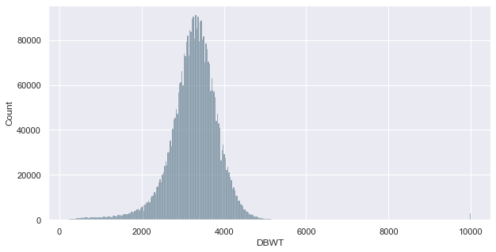

```python
# Histogram of the target variable
sns.histplot(birthdata['DBWT'], bins=350, color='#607c8e')
```

```python
# Computing the Skewness and the Kurtosis of the Birth Weight variable
print("Skewness of the Birthweight is : %f" % birthdata['DBWT'].skew())
print("Kurtosis of the birthweight is : %f" % birthdata['DBWT'].kurt())
```

```
Skewness of the Birthweight is : 0.231792
Kurtosis of the birthweight is : 12.607424
```

```python
# Looking at the distribution of the target variable
print("DBWT Variable")
print("Mean:",birthdata['DBWT'].mean())
print("stdev ",np.std(birthdata['DBWT']))
print("Min:", birthdata['DBWT'].min())
print("Max:",birthdata['DBWT'].max())
print("25% percentile: ",np.percentile(birthdata['DBWT'], 25))
print("Median:",np.percentile(birthdata['DBWT'], 50))
print("75% Percentile: ",np.percentile(birthdata['DBWT'], 75))
```

```
DBWT Variable
Mean: 3266.895145222955
stdev  619.4422019745625
Min: 227
Max: 9999
25% percentile:  2960.0
Median: 3300.0
75% Percentile:  3629.0
```

### Visualizations on the data

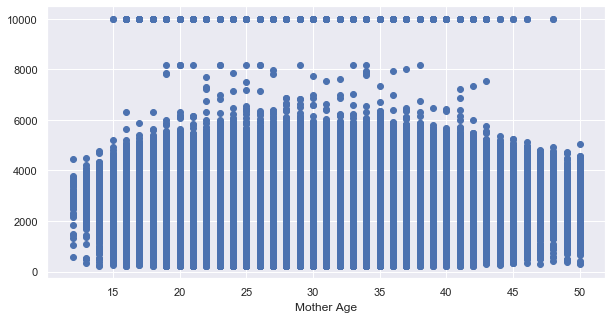

```python
plt.scatter(birthdata['MAGER'], birthdata['DBWT'])

plt.xlabel('Mother Age')
```

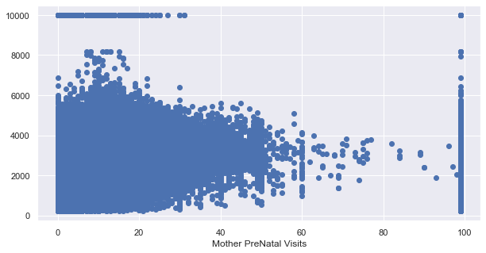

```python
plt.scatter(birthdata['PREVIS'], birthdata['DBWT'])

plt.xlabel('Mother PreNatal Visits')
```

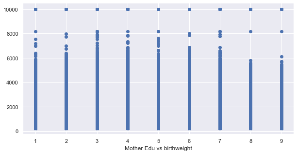

```python
plt.scatter(birthdata['MEDUC'], birthdata['DBWT'])

plt.xlabel('Mother Edu vs birthweight')
```

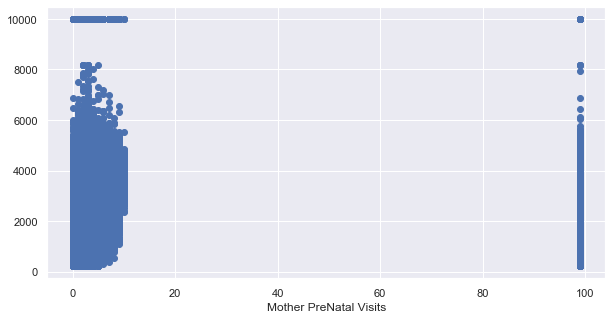

```python
plt.scatter(birthdata['PRECARE'], birthdata['DBWT'])

plt.xlabel('Mother PreNatal Visits')
```

```python
# Listing unique value counts in each feature

def getUniqueValues(data):
    colNames = data.columns
    listUnique = []
    for col in colNames:
        listUnique.append([col, data[col].nunique()])

    d1 = pd.DataFrame(listUnique)
    d1.columns = ['Feature Name', 'Unique Value']
    d1 = d1.sort_values(by='Unique Value', ascending=False)
    return d1

getUniqueValues(birthdata)
```

|  | Feature Name | Unique Value |
| --- | --- | --- |
| 4 | DBWT | 5357 |
| 9 | DOB_TT | 1441 |
| 2 | BMI | 567 |
| 12 | DWgt_R | 302 |
| 48 | PWgt_R | 302 |
| 21 | ILP_R | 300 |
| 20 | ILOP_R | 300 |
| 19 | ILLB_R | 300 |
| 54 | WTGAIN | 100 |
| 44 | PREVIS | 85 |
| 13 | FAGECOMB | 80 |
| 3 | CIG_0 | 73 |
| 37 | M_Ht_In | 48 |
| 25 | MAGER | 39 |
| 17 | FRACE31 | 32 |
| 33 | MRACE31 | 31 |
| 47 | PRIORTERM | 30 |
| 46 | PRIORLIVE | 20 |
| 16 | FRACE15 | 16 |
| 32 | MRACE15 | 15 |
| 45 | PRIORDEAD | 15 |
| 52 | RF_CESARN | 13 |
| 5 | DLMP_MM | 13 |
| 8 | DOB_MM | 12 |
| 43 | PRECARE | 12 |
| 14 | FEDUC | 9 |
| 29 | MEDUC | 9 |
| 1 | BFACIL | 8 |
| 30 | MHISPX | 8 |
| 41 | PAY | 8 |
| 15 | FHISPX | 8 |
| 49 | RDMETH_REC | 7 |
| 18 | FRACE6 | 7 |
| 10 | DOB_WK | 7 |
| 35 | MRAVE6 | 6 |
| 0 | ATTEND | 6 |
| 42 | PAY_REC | 5 |
| 6 | DLMP_YY | 4 |
| 50 | RESTATUS | 4 |
| 36 | MTRAN | 3 |
| 23 | IP_GON | 3 |
| 51 | RF_CESAR | 3 |
| 7 | DMAR | 3 |
| 24 | LD_INDL | 3 |
| 28 | MBSTATE_REC | 3 |
| 31 | MM_AICU | 3 |
| 40 | NO_RISKS | 3 |
| 39 | NO_MMORB | 3 |
| 38 | NO_INFEC | 3 |
| 26 | MAGE_IMPFLG | 2 |
| 34 | MRACEIMP | 2 |
| 22 | IMP_SEX | 2 |
| 53 | SEX | 2 |
| 27 | MAR_IMP | 2 |
| 11 | DOB_YY | 1 |

```python
# Checking data types of the data and group them
birthdata.columns.to_series().groupby(birthdata.dtypes).groups
```

```
{dtype('int64'): Index(['ATTEND', 'BFACIL', 'CIG_0', 'DBWT', 'DLMP_MM', 'DLMP_YY', 'DOB_MM',
        'DOB_TT', 'DOB_WK', 'DOB_YY', 'DWgt_R', 'FAGECOMB', 'FEDUC', 'FHISPX',
        'FRACE15', 'FRACE31', 'FRACE6', 'ILLB_R', 'ILOP_R', 'ILP_R', 'MAGER',
        'MBSTATE_REC', 'MEDUC', 'MHISPX', 'MRACE15', 'MRACE31', 'MRAVE6',
        'M_Ht_In', 'NO_INFEC', 'NO_MMORB', 'NO_RISKS', 'PAY', 'PAY_REC',
        'PRECARE', 'PREVIS', 'PRIORDEAD', 'PRIORLIVE', 'PRIORTERM', 'PWgt_R',
        'RDMETH_REC', 'RESTATUS', 'RF_CESARN', 'WTGAIN'],
       dtype='object'),
 dtype('float64'): Index(['BMI'], dtype='object'),
 dtype('O'): Index(['DMAR', 'IMP_SEX', 'IP_GON', 'LD_INDL', 'MAGE_IMPFLG', 'MAR_IMP',
        'MM_AICU', 'MRACEIMP', 'MTRAN', 'RF_CESAR', 'SEX'],
       dtype='object')}
```

# Data Preprocessing And Feature Engineering

#### Steps

1. Remove Duplicate
2. Drop Single value column
3. Find missing value
4. Visualize missing value
5. Impute missing value
6. Find Outliers
7. Feature engineering

#### 1. Remove Duplicate

```python
# Checking the length of the duplicates data
print(len(birthdata[birthdata.duplicated()]))
```

```
36
```

```python
# We have 36 duplicate values, keeping the first occurance and dropping the remaining duplicate values
birthdata.drop_duplicates(keep='first', inplace = True)
```

#### 2.Drop Single value column

```python
# Checking for any single value columns and dropping them
def removeSingleValueColumns(data):
    d1 = data.copy()
    for col in d1.columns:
        if d1[col].nunique() == 1:
            d1 = d1.drop([col], axis=1)
    return d1

birthdata=removeSingleValueColumns(birthdata)
```

```python
birthdata.shape
```

```
(3801498, 54)
```

#### 3. Find missing value

```python
# The columns have values like 9,99,999,9999,U etc which are Unknown or not stated per the readings provided,
#so considring these as missing value

cols9=["ATTEND","BFACIL","DMAR","FEDUC","FHISPX","FRACE6","MHISPX","NO_INFEC","NO_MMORB","NO_RISKS","PAY","PAY_REC","RDMETH_REC"]
cols99=["CIG_0","DLMP_MM","FAGECOMB","FRACE15","FRACE31","M_Ht_In","PRECARE","PREVIS","PRIORDEAD","PRIORLIVE","PRIORTERM","RF_CESARN","WTGAIN"]
cols99_9=["BMI"]
cols999=["DWgt_R","ILLB_R","ILOP_R","ILP_R"]
cols9999=["DBWT","DLMP_YY","DOB_TT","PWgt_R"]
colsu=["IP_GON","LD_INDL","MM_AICU","MTRAN","RF_CESAR"]
```

```python
# Keeping a copy of dataset
birthdata_main=birthdata
```

```python
# Repalcing the outliers with nan
birthdata[cols9] = birthdata[cols9].replace({'9':np.nan, 9:np.nan})
birthdata[cols99] = birthdata[cols99].replace({ 99:np.nan})
birthdata[cols99_9] = birthdata[cols99_9].replace({99.9:np.nan})
birthdata[cols999] = birthdata[cols999].replace({999:np.nan})
birthdata[cols9999] = birthdata[cols9999].replace({9999:np.nan})
birthdata[colsu] = birthdata[colsu].replace({'U':np.nan})
```

```python
# Missing value count

birthdata.replace(' ', np.nan, inplace=True,regex=True)
birthdata.isnull().sum()
```

```
ATTEND            2507
BFACIL             272
BMI              86198
CIG_0            18169
DBWT              2959
DLMP_MM         177751
DLMP_YY         166846
DMAR            456082
DOB_MM               0
DOB_TT             315
DOB_WK               0
DWgt_R           56046
FAGECOMB        441142
FEDUC           522349
FHISPX          485402
FRACE15         686901
FRACE31         686901
FRACE6          686901
ILLB_R          122102
ILOP_R          378073
ILP_R           457136
IMP_SEX        3801408
IP_GON            8573
LD_INDL           4207
MAGER                0
MAGE_IMPFLG    3801025
MAR_IMP        3799503
MBSTATE_REC          0
MEDUC                0
MHISPX           34037
MM_AICU           3551
MRACE15              0
MRACE31              0
MRACEIMP       3561310
MRAVE6               0
MTRAN             1919
M_Ht_In          19980
NO_INFEC          8573
NO_MMORB          3551
NO_RISKS          2973
PAY              22744
PAY_REC          22744
PRECARE          95671
PREVIS           95616
PRIORDEAD        10245
PRIORLIVE         7717
PRIORTERM        12775
PWgt_R               0
RDMETH_REC        1628
RESTATUS             0
RF_CESAR          2973
RF_CESARN         4054
SEX                  0
WTGAIN          117185
dtype: int64
```

#### 4. Visualize missing value

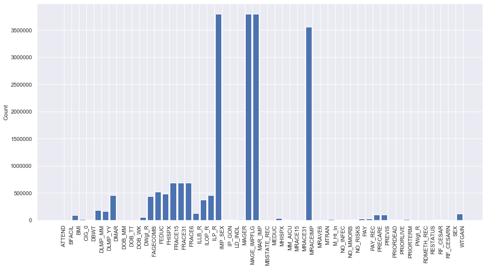

```python
# Define function to visualize the count
def GraphMissingValueCount(data):
    missingCount = data.isnull().sum()
    plt.figure(figsize=(16, 8))
    plt.xticks(np.arange(len(missingCount)) + 0.5, missingCount.index, rotation='vertical')
    plt.ylabel('Count')
    plt.bar(np.arange(len(missingCount)), missingCount)
    plt.show()



GraphMissingValueCount(birthdata)
```

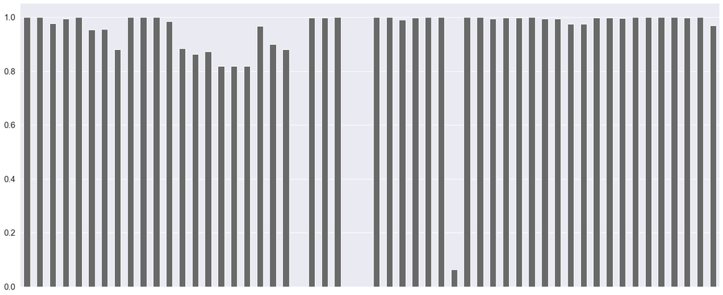

```python
# Using msno to understand the distribution of missing values through bar and heatmap visualizations
msno.bar(birthdata)
```

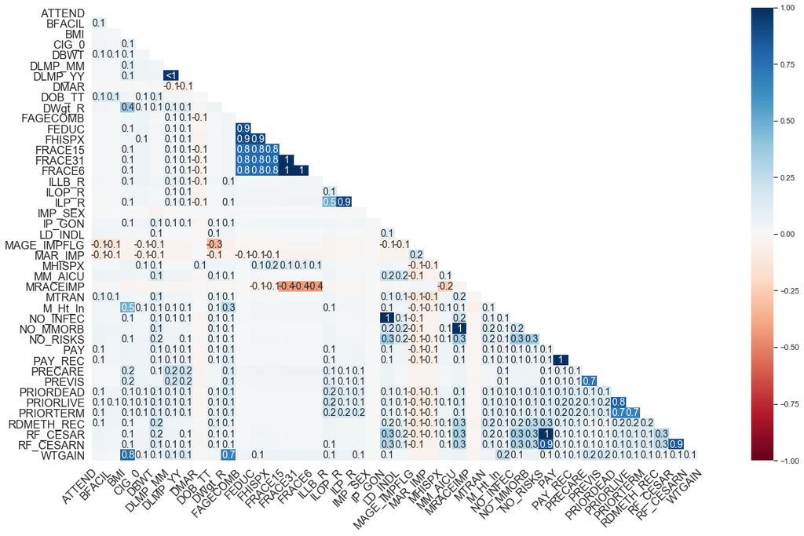

```python
msno.heatmap(birthdata)
```

```python
# Calculate the missing value %
percent_missing = birthdata.isnull().sum() * 100 / len(birthdata)
missing_value_df = pd.DataFrame({'column_name': birthdata.columns,
                                 'percent_missing': percent_missing})
missing_value_df.sort_values('percent_missing', ascending=False,inplace=True)
```

```python
print("Missing value percentage: ")
missing_value_df
```

```
Missing value percentage:
```

|  | column_name | percent_missing |
| --- | --- | --- |
| IMP_SEX | IMP_SEX | 99.997633 |
| MAGE_IMPFLG | MAGE_IMPFLG | 99.987558 |
| MAR_IMP | MAR_IMP | 99.947521 |
| MRACEIMP | MRACEIMP | 93.681754 |
| FRACE31 | FRACE31 | 18.069219 |
| FRACE6 | FRACE6 | 18.069219 |
| FRACE15 | FRACE15 | 18.069219 |
| FEDUC | FEDUC | 13.740610 |
| FHISPX | FHISPX | 12.768703 |
| ILP_R | ILP_R | 12.025154 |
| DMAR | DMAR | 11.997428 |
| FAGECOMB | FAGECOMB | 11.604425 |
| ILOP_R | ILOP_R | 9.945369 |
| DLMP_MM | DLMP_MM | 4.675815 |
| DLMP_YY | DLMP_YY | 4.388954 |
| ILLB_R | ILLB_R | 3.211944 |
| WTGAIN | WTGAIN | 3.082601 |
| PRECARE | PRECARE | 2.516666 |
| PREVIS | PREVIS | 2.515219 |
| BMI | BMI | 2.267475 |
| DWgt_R | DWgt_R | 1.474314 |
| MHISPX | MHISPX | 0.895358 |
| PAY | PAY | 0.598290 |
| PAY_REC | PAY_REC | 0.598290 |
| M_Ht_In | M_Ht_In | 0.525582 |
| CIG_0 | CIG_0 | 0.477943 |
| PRIORTERM | PRIORTERM | 0.336052 |
| PRIORDEAD | PRIORDEAD | 0.269499 |
| IP_GON | IP_GON | 0.225516 |
| NO_INFEC | NO_INFEC | 0.225516 |
| PRIORLIVE | PRIORLIVE | 0.202999 |
| LD_INDL | LD_INDL | 0.110667 |
| RF_CESARN | RF_CESARN | 0.106642 |
| MM_AICU | MM_AICU | 0.093411 |
| NO_MMORB | NO_MMORB | 0.093411 |
| RF_CESAR | RF_CESAR | 0.078206 |
| NO_RISKS | NO_RISKS | 0.078206 |
| DBWT | DBWT | 0.077838 |
| ATTEND | ATTEND | 0.065948 |
| MTRAN | MTRAN | 0.050480 |
| RDMETH_REC | RDMETH_REC | 0.042825 |
| DOB_TT | DOB_TT | 0.008286 |
| BFACIL | BFACIL | 0.007155 |
| MRAVE6 | MRAVE6 | 0.000000 |
| MRACE31 | MRACE31 | 0.000000 |
| MRACE15 | MRACE15 | 0.000000 |
| MEDUC | MEDUC | 0.000000 |
| MAGER | MAGER | 0.000000 |
| DOB_WK | DOB_WK | 0.000000 |
| PWgt_R | PWgt_R | 0.000000 |
| RESTATUS | RESTATUS | 0.000000 |
| DOB_MM | DOB_MM | 0.000000 |
| SEX | SEX | 0.000000 |
| MBSTATE_REC | MBSTATE_REC | 0.000000 |

```python
# Dropping the column where missing value % is greater than 30
missing_drop = list(missing_value_df[missing_value_df.percent_missing>30].column_name)
birthdata = birthdata.drop(missing_drop, axis=1)
print("After droping column")
birthdata
```

```
After droping column
```

|  | ATTEND | BFACIL | BMI | CIG_0 | DBWT | DLMP_MM | DLMP_YY | DMAR | DOB_MM | DOB_TT | DOB_WK | DWgt_R | FAGECOMB | FEDUC | FHISPX | FRACE15 | FRACE31 | FRACE6 | ILLB_R | ILOP_R | ILP_R | IP_GON | LD_INDL | MAGER | MBSTATE_REC | MEDUC | MHISPX | MM_AICU | MRACE15 | … |
| --- | --- | --- | --- | --- | --- | --- | --- | --- | --- | --- | --- | --- | --- | --- | --- | --- | --- | --- | --- | --- | --- | --- | --- | --- | --- | --- | --- | --- | --- | --- |
| 0 | 1.0 | 1.0 | 30.7 | 0.0 | 3657.0 | 4.0 | 2017.0 | 1 | 1 | 1227.0 | 2 | 231.0 | 31.0 | 3.0 | 1.0 | 1.0 | 1.0 | 1.0 | 16.0 | 33.0 | 16.0 | N | N | 30 | 1 | 6 | 0.0 | N | 1 | … |
| 1 | 1.0 | 1.0 | 33.3 | 2.0 | 3242.0 | NaN | NaN | 2 | 1 | 1704.0 | 2 | 185.0 | 35.0 | 4.0 | 0.0 | 3.0 | 3.0 | 3.0 | 180.0 | 888.0 | 180.0 | N | N | 35 | 1 | 9 | 0.0 | N | 3 | … |
| 2 | 1.0 | 1.0 | 30.0 | 0.0 | 3470.0 | 4.0 | 2017.0 | 1 | 1 | 336.0 | 2 | 273.0 | 31.0 | 4.0 | 0.0 | 1.0 | 1.0 | 1.0 | NaN | 888.0 | NaN | N | N | 28 | 1 | 6 | 0.0 | N | 1 | … |
| 3 | 3.0 | 1.0 | 23.7 | 0.0 | 3140.0 | 5.0 | 2017.0 | 2 | 1 | 938.0 | 2 | 138.0 | 26.0 | 2.0 | 0.0 | 3.0 | 3.0 | 3.0 | 43.0 | 888.0 | 43.0 | N | N | 23 | 1 | 2 | 0.0 | N | 3 | … |
| 4 | 1.0 | 1.0 | 35.5 | 0.0 | 2125.0 | NaN | NaN | 1 | 1 | 830.0 | 3 | 219.0 | 35.0 | 3.0 | 0.0 | 2.0 | 2.0 | 2.0 | NaN | NaN | NaN | N | N | 37 | 1 | 4 | 0.0 | N | 1 | … |
| ... | ... | ... | ... | ... | ... | ... | ... | ... | ... | ... | ... | ... | ... | ... | ... | ... | ... | ... | ... | ... | ... | ... | ... | ... | ... | ... | ... | ... | ... | … |
| 3801529 | 1.0 | 1.0 | 26.3 | 0.0 | 2140.0 | 4.0 | 2018.0 | 2 | 12 | 1531.0 | 2 | 215.0 | 31.0 | 3.0 | 2.0 | 1.0 | 1.0 | 1.0 | NaN | 888.0 | NaN | N | N | 32 | 1 | 3 | 0.0 | N | 2 | … |
| 3801530 | 1.0 | 1.0 | 32.4 | 0.0 | 3560.0 | 3.0 | 2018.0 | 2 | 12 | 2347.0 | 2 | 205.0 | 31.0 | 2.0 | 4.0 | 1.0 | 1.0 | 1.0 | 43.0 | NaN | NaN | N | N | 23 | 2 | 2 | 4.0 | N | 1 | … |
| 3801531 | 5.0 | 7.0 | 27.6 | 0.0 | 3367.0 | 3.0 | 2018.0 | 2 | 11 | 1354.0 | 2 | 178.0 | 45.0 | 3.0 | 0.0 | 5.0 | 4.0 | 4.0 | NaN | NaN | NaN | N | N | 35 | 2 | 3 | 0.0 | N | 5 | … |
| 3801532 | 5.0 | 4.0 | NaN | 98.0 | 320.0 | 3.0 | 2018.0 | 2 | 8 | 859.0 | 2 | NaN | NaN | NaN | NaN | NaN | NaN | NaN | 888.0 | 888.0 | 888.0 | NaN | NaN | 36 | 3 | 9 | 2.0 | NaN | 1 | … |
| 3801533 | 1.0 | 1.0 | 42.1 | 0.0 | 2455.0 | 2.0 | 2018.0 | 1 | 11 | 1018.0 | 7 | 302.0 | 30.0 | 3.0 | 0.0 | 2.0 | 2.0 | 2.0 | 888.0 | 888.0 | 888.0 | N | N | 30 | 1 | 5 | 6.0 | N | 2 | … |

3801498 rows × 50 columns

```python
# missing value count after 30% column drop
birthdata.isnull().sum()
```

```
ATTEND           2507
BFACIL            272
BMI             86198
CIG_0           18169
DBWT             2959
DLMP_MM        177751
DLMP_YY        166846
DMAR           456082
DOB_MM              0
DOB_TT            315
DOB_WK              0
DWgt_R          56046
FAGECOMB       441142
FEDUC          522349
FHISPX         485402
FRACE15        686901
FRACE31        686901
FRACE6         686901
ILLB_R         122102
ILOP_R         378073
ILP_R          457136
IP_GON           8573
LD_INDL          4207
MAGER               0
MBSTATE_REC         0
MEDUC               0
MHISPX          34037
MM_AICU          3551
MRACE15             0
MRACE31             0
MRAVE6              0
MTRAN            1919
M_Ht_In         19980
NO_INFEC         8573
NO_MMORB         3551
NO_RISKS         2973
PAY             22744
PAY_REC         22744
PRECARE         95671
PREVIS          95616
PRIORDEAD       10245
PRIORLIVE        7717
PRIORTERM       12775
PWgt_R              0
RDMETH_REC       1628
RESTATUS            0
RF_CESAR         2973
RF_CESARN        4054
SEX                 0
WTGAIN         117185
dtype: int64
```

#### 5. Impute missing value

```python
# Determine the type of variable for missing value imputation
objectTypeFeature = [f for f in birthdata.columns if birthdata.dtypes[f] == 'object']
print('Object features are :',objectTypeFeature)
```

```
Object features are : ['DMAR', 'IP_GON', 'LD_INDL', 'MM_AICU', 'MTRAN', 'RF_CESAR', 'SEX']
```

```python
#To impute the object fetaures,we will define a maximum no of unique values in a column.
#this max value is the maximum number of unique entries for a given feature, which will
#help us determine that a particular feature is categorical in nature.
```

```python
# fetch the columns of the dataset
featureset = birthdata.columns
```

```python
maxi = 10 #threshold value
catcolumns = []
numColumns=[]
for i in featureset:
    if birthdata[i].nunique() < maxi:
        catcolumns.append(i)
    else:
        numColumns.append(i)

print("Total Number of features identified as categorical: ")
print(len(catcolumns))

print("Total Number of features identified as numericals: ")
print(len(numColumns))
```

```
Total Number of features identified as categorical:
25
Total Number of features identified as numericals:
25
```

```python
print("Categorical features are as below: ")

print(catcolumns)

print("Numerical features are as below: ")

print(numColumns)
```

```
Categorical features are as below:
['ATTEND', 'BFACIL', 'DLMP_YY', 'DMAR', 'DOB_WK', 'FEDUC', 'FHISPX', 'FRACE6', 'IP_GON', 'LD_INDL', 'MBSTATE_REC', 'MEDUC', 'MHISPX', 'MM_AICU', 'MRAVE6', 'MTRAN', 'NO_INFEC', 'NO_MMORB', 'NO_RISKS', 'PAY', 'PAY_REC', 'RDMETH_REC', 'RESTATUS', 'RF_CESAR', 'SEX']
Numerical features are as below:
['BMI', 'CIG_0', 'DBWT', 'DLMP_MM', 'DOB_MM', 'DOB_TT', 'DWgt_R', 'FAGECOMB', 'FRACE15', 'FRACE31', 'ILLB_R', 'ILOP_R', 'ILP_R', 'MAGER', 'MRACE15', 'MRACE31', 'M_Ht_In', 'PRECARE', 'PREVIS', 'PRIORDEAD', 'PRIORLIVE', 'PRIORTERM', 'PWgt_R', 'RF_CESARN', 'WTGAIN']
```

```python
# function to replace NAN values with mean value

def meanImpute(DataFrame,ColName):

     mean=DataFrame[ColName].mean()

    # replace nan values with most occured category
     DataFrame[ColName].fillna(mean,inplace=True)
```

```python
# Call function to impute with mean val
for Columns in numColumns:
    meanImpute(birthdata,Columns)
```

```python
# function to replace NAN values with mode value

def modeImpute(DataFrame,ColName):

     mode=DataFrame[ColName].mode()[0]

    # replace nan values with most occured category
     DataFrame[ColName].fillna(mode,inplace=True)
```

```python
#Call function to impute with mode
for Columns in catcolumns:
    modeImpute(birthdata,Columns)
```

```python
print("Count of missing value after imputation")
birthdata.isnull().sum()
```

```
Count of missing value after imputation
```

```
ATTEND         0
BFACIL         0
BMI            0
CIG_0          0
DBWT           0
DLMP_MM        0
DLMP_YY        0
DMAR           0
DOB_MM         0
DOB_TT         0
DOB_WK         0
DWgt_R         0
FAGECOMB       0
FEDUC          0
FHISPX         0
FRACE15        0
FRACE31        0
FRACE6         0
ILLB_R         0
ILOP_R         0
ILP_R          0
IP_GON         0
LD_INDL        0
MAGER          0
MBSTATE_REC    0
MEDUC          0
MHISPX         0
MM_AICU        0
MRACE15        0
MRACE31        0
MRAVE6         0
MTRAN          0
M_Ht_In        0
NO_INFEC       0
NO_MMORB       0
NO_RISKS       0
PAY            0
PAY_REC        0
PRECARE        0
PREVIS         0
PRIORDEAD      0
PRIORLIVE      0
PRIORTERM      0
PWgt_R         0
RDMETH_REC     0
RESTATUS       0
RF_CESAR       0
RF_CESARN      0
SEX            0
WTGAIN         0
dtype: int64
```

```python
birthdata.describe().round(2)
```

|  | ATTEND | BFACIL | BMI | CIG_0 | DBWT | DLMP_MM | DLMP_YY | DOB_MM | DOB_TT | DOB_WK | DWgt_R | FAGECOMB | FEDUC | FHISPX | FRACE15 | FRACE31 | FRACE6 | ILLB_R | ILOP_R | ILP_R | MAGER | MBSTATE_REC | MEDUC | MHISPX | MRACE15 | MRACE31 | MRAVE6 | M_Ht_In | NO_INFEC | … |
| --- | --- | --- | --- | --- | --- | --- | --- | --- | --- | --- | --- | --- | --- | --- | --- | --- | --- | --- | --- | --- | --- | --- | --- | --- | --- | --- | --- | --- | --- | --- |
| count | 3801498.00 | 3801498.00 | 3801498.00 | 3801498.00 | 3801498.00 | 3801498.00 | 3801498.00 | 3801498.00 | 3801498.00 | 3801498.00 | 3801498.00 | 3801498.0 | 3801498.00 | 3801498.0 | 3801498.00 | 3801498.00 | 3801498.00 | 3801498.00 | 3801498.00 | 3801498.00 | 3801498.00 | 3801498.00 | 3801498.00 | 3801498.00 | 3801498.00 | 3801498.00 | 3801498.00 | 3801498.00 | 3801498.00 | … |
| mean | 1.33 | 1.04 | 27.17 | 1.11 | 3261.66 | 6.61 | 2017.24 | 6.56 | 1228.45 | 4.06 | 188.32 | 31.8 | 4.08 | 0.5 | 1.91 | 1.62 | 1.42 | 377.13 | 723.70 | 338.11 | 29.01 | 1.23 | 4.41 | 0.57 | 1.94 | 1.63 | 1.52 | 64.12 | 0.97 | … |
| std | 0.75 | 0.32 | 6.68 | 4.73 | 590.24 | 3.39 | 0.43 | 3.42 | 631.56 | 1.85 | 41.09 | 6.4 | 1.68 | 1.3 | 2.38 | 1.63 | 1.02 | 403.61 | 317.06 | 378.88 | 5.81 | 0.43 | 1.80 | 1.37 | 2.69 | 1.82 | 1.11 | 2.83 | 0.16 | … |
| min | 1.00 | 1.00 | 13.00 | 0.00 | 227.00 | 1.00 | 2016.00 | 1.00 | 0.00 | 1.00 | 100.00 | 11.0 | 1.00 | 0.0 | 1.00 | 1.00 | 1.00 | 3.00 | 3.00 | 3.00 | 12.00 | 1.00 | 1.00 | 0.00 | 1.00 | 1.00 | 1.00 | 30.00 | 0.00 | … |
| 25% | 1.00 | 1.00 | 22.30 | 0.00 | 2960.00 | 4.00 | 2017.00 | 4.00 | 759.00 | 3.00 | 160.00 | 28.0 | 3.00 | 0.0 | 1.00 | 1.00 | 1.00 | 32.00 | 723.70 | 28.00 | 25.00 | 1.00 | 3.00 | 0.00 | 1.00 | 1.00 | 1.00 | 62.00 | 1.00 | … |
| 50% | 1.00 | 1.00 | 25.80 | 0.00 | 3300.00 | 6.61 | 2017.00 | 7.00 | 1236.00 | 4.00 | 182.00 | 31.8 | 3.00 | 0.0 | 1.00 | 1.00 | 1.00 | 84.00 | 888.00 | 81.00 | 29.00 | 1.00 | 4.00 | 0.00 | 1.00 | 1.00 | 1.00 | 64.00 | 1.00 | … |
| 75% | 1.00 | 1.00 | 30.50 | 0.00 | 3629.00 | 10.00 | 2017.00 | 9.00 | 1733.00 | 6.00 | 210.00 | 35.0 | 6.00 | 0.0 | 1.91 | 1.62 | 1.00 | 888.00 | 888.00 | 888.00 | 33.00 | 1.00 | 6.00 | 0.00 | 2.00 | 2.00 | 2.00 | 66.00 | 1.00 | … |
| max | 5.00 | 7.00 | 69.90 | 98.00 | 8165.00 | 12.00 | 2018.00 | 12.00 | 2359.00 | 7.00 | 400.00 | 98.0 | 8.00 | 6.0 | 15.00 | 31.00 | 6.00 | 888.00 | 888.00 | 888.00 | 50.00 | 3.00 | 9.00 | 6.00 | 15.00 | 31.00 | 6.00 | 78.00 | 1.00 | … |

#### 6. Find Outliers

```python
#checking for outliers manually
birthdata.describe(percentiles=[.25,.5,.75,.90,.95,.99])
```

|  | ATTEND | BFACIL | BMI | CIG_0 | DBWT | DLMP_MM | DLMP_YY | DOB_MM | DOB_TT | DOB_WK | DWgt_R | FAGECOMB | FEDUC | FHISPX | FRACE15 | FRACE31 | FRACE6 | ILLB_R | ILOP_R | ILP_R | MAGER | MBSTATE_REC | MEDUC | MHISPX | MRACE15 | MRACE31 | MRAVE6 | M_Ht_In | NO_INFEC | … |
| --- | --- | --- | --- | --- | --- | --- | --- | --- | --- | --- | --- | --- | --- | --- | --- | --- | --- | --- | --- | --- | --- | --- | --- | --- | --- | --- | --- | --- | --- | --- |
| count | 3.801498e+06 | 3.801498e+06 | 3.801498e+06 | 3.801498e+06 | 3.801498e+06 | 3.801498e+06 | 3.801498e+06 | 3.801498e+06 | 3.801498e+06 | 3.801498e+06 | 3.801498e+06 | 3.801498e+06 | 3.801498e+06 | 3.801498e+06 | 3.801498e+06 | 3.801498e+06 | 3.801498e+06 | 3.801498e+06 | 3.801498e+06 | 3.801498e+06 | 3.801498e+06 | 3.801498e+06 | 3.801498e+06 | 3.801498e+06 | 3.801498e+06 | 3.801498e+06 | 3.801498e+06 | 3.801498e+06 | 3.801498e+06 | … |
| mean | 1.326677e+00 | 1.035265e+00 | 2.716778e+01 | 1.105821e+00 | 3.261657e+03 | 6.608612e+00 | 2.017237e+03 | 6.560874e+00 | 1.228447e+03 | 4.059287e+00 | 1.883221e+02 | 3.180158e+01 | 4.081401e+00 | 4.976714e-01 | 1.909796e+00 | 1.621382e+00 | 1.418232e+00 | 3.771284e+02 | 7.237050e+02 | 3.381147e+02 | 2.900902e+01 | 1.232912e+00 | 4.412695e+00 | 5.690017e-01 | 1.942277e+00 | 1.633778e+00 | 1.522772e+00 | 6.412309e+01 | 9.724511e-01 | … |
| std | 7.480081e-01 | 3.153117e-01 | 6.682570e+00 | 4.731710e+00 | 5.902357e+02 | 3.394940e+00 | 4.268392e-01 | 3.419285e+00 | 6.315641e+02 | 1.852543e+00 | 4.109144e+01 | 6.403779e+00 | 1.683813e+00 | 1.297952e+00 | 2.384907e+00 | 1.633307e+00 | 1.016819e+00 | 4.036093e+02 | 3.170571e+02 | 3.788776e+02 | 5.806021e+00 | 4.273430e-01 | 1.804157e+00 | 1.367229e+00 | 2.689346e+00 | 1.815561e+00 | 1.112222e+00 | 2.827205e+00 | 1.636763e-01 | … |
| min | 1.000000e+00 | 1.000000e+00 | 1.300000e+01 | 0.000000e+00 | 2.270000e+02 | 1.000000e+00 | 2.016000e+03 | 1.000000e+00 | 0.000000e+00 | 1.000000e+00 | 1.000000e+02 | 1.100000e+01 | 1.000000e+00 | 0.000000e+00 | 1.000000e+00 | 1.000000e+00 | 1.000000e+00 | 3.000000e+00 | 3.000000e+00 | 3.000000e+00 | 1.200000e+01 | 1.000000e+00 | 1.000000e+00 | 0.000000e+00 | 1.000000e+00 | 1.000000e+00 | 1.000000e+00 | 3.000000e+01 | 0.000000e+00 | … |
| 25% | 1.000000e+00 | 1.000000e+00 | 2.230000e+01 | 0.000000e+00 | 2.960000e+03 | 4.000000e+00 | 2.017000e+03 | 4.000000e+00 | 7.590000e+02 | 3.000000e+00 | 1.600000e+02 | 2.800000e+01 | 3.000000e+00 | 0.000000e+00 | 1.000000e+00 | 1.000000e+00 | 1.000000e+00 | 3.200000e+01 | 7.237050e+02 | 2.800000e+01 | 2.500000e+01 | 1.000000e+00 | 3.000000e+00 | 0.000000e+00 | 1.000000e+00 | 1.000000e+00 | 1.000000e+00 | 6.200000e+01 | 1.000000e+00 | … |
| 50% | 1.000000e+00 | 1.000000e+00 | 2.580000e+01 | 0.000000e+00 | 3.300000e+03 | 6.608612e+00 | 2.017000e+03 | 7.000000e+00 | 1.236000e+03 | 4.000000e+00 | 1.820000e+02 | 3.180158e+01 | 3.000000e+00 | 0.000000e+00 | 1.000000e+00 | 1.000000e+00 | 1.000000e+00 | 8.400000e+01 | 8.880000e+02 | 8.100000e+01 | 2.900000e+01 | 1.000000e+00 | 4.000000e+00 | 0.000000e+00 | 1.000000e+00 | 1.000000e+00 | 1.000000e+00 | 6.400000e+01 | 1.000000e+00 | … |
| 75% | 1.000000e+00 | 1.000000e+00 | 3.050000e+01 | 0.000000e+00 | 3.629000e+03 | 1.000000e+01 | 2.017000e+03 | 9.000000e+00 | 1.733000e+03 | 6.000000e+00 | 2.100000e+02 | 3.500000e+01 | 6.000000e+00 | 0.000000e+00 | 1.909796e+00 | 1.621382e+00 | 1.000000e+00 | 8.880000e+02 | 8.880000e+02 | 8.880000e+02 | 3.300000e+01 | 1.000000e+00 | 6.000000e+00 | 0.000000e+00 | 2.000000e+00 | 2.000000e+00 | 2.000000e+00 | 6.600000e+01 | 1.000000e+00 | … |
| 90% | 3.000000e+00 | 1.000000e+00 | 3.640000e+01 | 0.000000e+00 | 3.930000e+03 | 1.100000e+01 | 2.018000e+03 | 1.100000e+01 | 2.110000e+03 | 7.000000e+00 | 2.430000e+02 | 4.000000e+01 | 6.000000e+00 | 1.000000e+00 | 2.000000e+00 | 2.000000e+00 | 2.000000e+00 | 8.880000e+02 | 8.880000e+02 | 8.880000e+02 | 3.700000e+01 | 2.000000e+00 | 7.000000e+00 | 2.000000e+00 | 3.000000e+00 | 3.000000e+00 | 3.000000e+00 | 6.800000e+01 | 1.000000e+00 | … |
| 95% | 3.000000e+00 | 1.000000e+00 | 4.030000e+01 | 1.000000e+01 | 4.120000e+03 | 1.200000e+01 | 2.018000e+03 | 1.200000e+01 | 2.231000e+03 | 7.000000e+00 | 2.660000e+02 | 4.300000e+01 | 7.000000e+00 | 4.000000e+00 | 5.000000e+00 | 4.000000e+00 | 4.000000e+00 | 8.880000e+02 | 8.880000e+02 | 8.880000e+02 | 3.900000e+01 | 2.000000e+00 | 7.000000e+00 | 4.000000e+00 | 8.000000e+00 | 4.000000e+00 | 4.000000e+00 | 6.900000e+01 | 1.000000e+00 | … |
| 99% | 4.000000e+00 | 3.000000e+00 | 4.820000e+01 | 2.000000e+01 | 4.508000e+03 | 1.200000e+01 | 2.018000e+03 | 1.200000e+01 | 2.341000e+03 | 7.000000e+00 | 3.160000e+02 | 5.000000e+01 | 8.000000e+00 | 6.000000e+00 | 1.500000e+01 | 1.000000e+01 | 6.000000e+00 | 8.880000e+02 | 8.880000e+02 | 8.880000e+02 | 4.200000e+01 | 2.000000e+00 | 9.000000e+00 | 6.000000e+00 | 1.500000e+01 | 1.000000e+01 | 6.000000e+00 | 7.100000e+01 | 1.000000e+00 | … |
| max | 5.000000e+00 | 7.000000e+00 | 6.990000e+01 | 9.800000e+01 | 8.165000e+03 | 1.200000e+01 | 2.018000e+03 | 1.200000e+01 | 2.359000e+03 | 7.000000e+00 | 4.000000e+02 | 9.800000e+01 | 8.000000e+00 | 6.000000e+00 | 1.500000e+01 | 3.100000e+01 | 6.000000e+00 | 8.880000e+02 | 8.880000e+02 | 8.880000e+02 | 5.000000e+01 | 3.000000e+00 | 9.000000e+00 | 6.000000e+00 | 1.500000e+01 | 3.100000e+01 | 6.000000e+00 | 7.800000e+01 | 1.000000e+00 | … |

```python
objCol=objectTypeFeature
```

```python
objectTypeFeature.remove('DMAR')
```

```python
#In order to further use the data in outlier detection convert object fields to numerical

#Define the function to perform encoding
def func_labelEncoder(data, columns):
    d1 = data.copy()
    for i in columns:
        le = LabelEncoder()
        d1[i] = le.fit_transform(d1[i])
    return d1

#Call the function
df_encoded=func_labelEncoder(birthdata,objectTypeFeature)
```

```python
df_encoded
```

|  | ATTEND | BFACIL | BMI | CIG_0 | DBWT | DLMP_MM | DLMP_YY | DMAR | DOB_MM | DOB_TT | DOB_WK | DWgt_R | FAGECOMB | FEDUC | FHISPX | FRACE15 | FRACE31 | FRACE6 | ILLB_R | ILOP_R | ILP_R | IP_GON | LD_INDL | MAGER | MBSTATE_REC | MEDUC | MHISPX | MM_AICU | MRACE15 | … |
| --- | --- | --- | --- | --- | --- | --- | --- | --- | --- | --- | --- | --- | --- | --- | --- | --- | --- | --- | --- | --- | --- | --- | --- | --- | --- | --- | --- | --- | --- | --- |
| 0 | 1.0 | 1.0 | 30.700000 | 0.0 | 3657.0 | 4.000000 | 2017.0 | 1 | 1 | 1227.0 | 2 | 231.000000 | 31.000000 | 3.0 | 1.0 | 1.000000 | 1.000000 | 1.0 | 16.000000 | 33.000000 | 16.000000 | 0 | 0 | 30 | 1 | 6 | 0.0 | 0 | 1 | … |
| 1 | 1.0 | 1.0 | 33.300000 | 2.0 | 3242.0 | 6.608612 | 2017.0 | 2 | 1 | 1704.0 | 2 | 185.000000 | 35.000000 | 4.0 | 0.0 | 3.000000 | 3.000000 | 3.0 | 180.000000 | 888.000000 | 180.000000 | 0 | 0 | 35 | 1 | 9 | 0.0 | 0 | 3 | … |
| 2 | 1.0 | 1.0 | 30.000000 | 0.0 | 3470.0 | 4.000000 | 2017.0 | 1 | 1 | 336.0 | 2 | 273.000000 | 31.000000 | 4.0 | 0.0 | 1.000000 | 1.000000 | 1.0 | 377.128382 | 888.000000 | 338.114723 | 0 | 0 | 28 | 1 | 6 | 0.0 | 0 | 1 | … |
| 3 | 3.0 | 1.0 | 23.700000 | 0.0 | 3140.0 | 5.000000 | 2017.0 | 2 | 1 | 938.0 | 2 | 138.000000 | 26.000000 | 2.0 | 0.0 | 3.000000 | 3.000000 | 3.0 | 43.000000 | 888.000000 | 43.000000 | 0 | 0 | 23 | 1 | 2 | 0.0 | 0 | 3 | … |
| 4 | 1.0 | 1.0 | 35.500000 | 0.0 | 2125.0 | 6.608612 | 2017.0 | 1 | 1 | 830.0 | 3 | 219.000000 | 35.000000 | 3.0 | 0.0 | 2.000000 | 2.000000 | 2.0 | 377.128382 | 723.704988 | 338.114723 | 0 | 0 | 37 | 1 | 4 | 0.0 | 0 | 1 | … |
| ... | ... | ... | ... | ... | ... | ... | ... | ... | ... | ... | ... | ... | ... | ... | ... | ... | ... | ... | ... | ... | ... | ... | ... | ... | ... | ... | ... | ... | ... | … |
| 3801529 | 1.0 | 1.0 | 26.300000 | 0.0 | 2140.0 | 4.000000 | 2018.0 | 2 | 12 | 1531.0 | 2 | 215.000000 | 31.000000 | 3.0 | 2.0 | 1.000000 | 1.000000 | 1.0 | 377.128382 | 888.000000 | 338.114723 | 0 | 0 | 32 | 1 | 3 | 0.0 | 0 | 2 | … |
| 3801530 | 1.0 | 1.0 | 32.400000 | 0.0 | 3560.0 | 3.000000 | 2018.0 | 2 | 12 | 2347.0 | 2 | 205.000000 | 31.000000 | 2.0 | 4.0 | 1.000000 | 1.000000 | 1.0 | 43.000000 | 723.704988 | 338.114723 | 0 | 0 | 23 | 2 | 2 | 4.0 | 0 | 1 | … |
| 3801531 | 5.0 | 7.0 | 27.600000 | 0.0 | 3367.0 | 3.000000 | 2018.0 | 2 | 11 | 1354.0 | 2 | 178.000000 | 45.000000 | 3.0 | 0.0 | 5.000000 | 4.000000 | 4.0 | 377.128382 | 723.704988 | 338.114723 | 0 | 0 | 35 | 2 | 3 | 0.0 | 0 | 5 | … |
| 3801532 | 5.0 | 4.0 | 27.167775 | 98.0 | 320.0 | 3.000000 | 2018.0 | 2 | 8 | 859.0 | 2 | 188.322092 | 31.801577 | 3.0 | 0.0 | 1.909796 | 1.621382 | 1.0 | 888.000000 | 888.000000 | 888.000000 | 0 | 0 | 36 | 3 | 9 | 2.0 | 0 | 1 | … |
| 3801533 | 1.0 | 1.0 | 42.100000 | 0.0 | 2455.0 | 2.000000 | 2018.0 | 1 | 11 | 1018.0 | 7 | 302.000000 | 30.000000 | 3.0 | 0.0 | 2.000000 | 2.000000 | 2.0 | 888.000000 | 888.000000 | 888.000000 | 0 | 0 | 30 | 1 | 5 | 6.0 | 0 | 2 | … |

3801498 rows × 50 columns

```python
#Scaling the data for outlier visualization

def func_minMaxScaler(data):
    scaler = MinMaxScaler()
    dfScaled = scaler.fit_transform(data)
    dfScaled = pd.DataFrame(dfScaled, columns=data.columns)
    return dfScaled

dfScaled=func_minMaxScaler(df_encoded)
```

```python
# Visualizing the outliers

def func_visualizeOutlier(scaledData):
    fig= plt.figure(figsize=(20,20))
    sns.boxplot(data=scaledData)
    plt.show()
```

```
BoxPlot for numerical variable
```

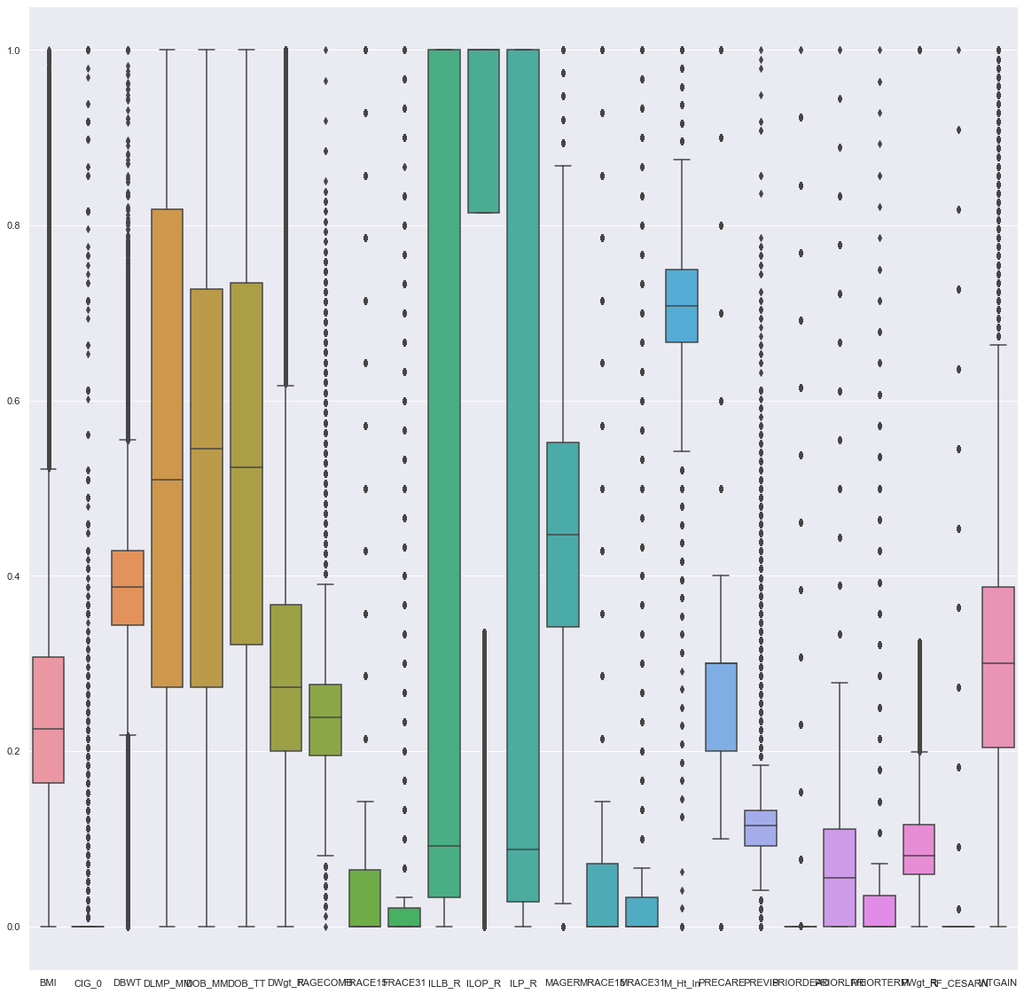

```python
print("BoxPlot for numerical variable")
func_visualizeOutlier(dfScaled[numColumns])
```

```
BoxPlot for categorical variable
```

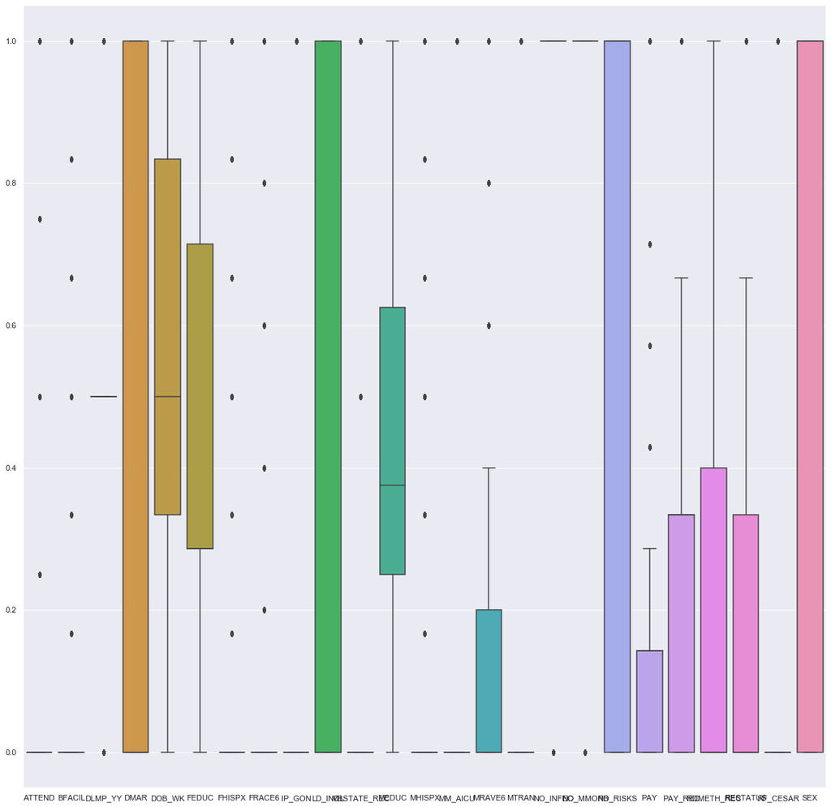

```python
print("BoxPlot for categorical variable")
func_visualizeOutlier(dfScaled[catcolumns])
```

#### Outlier Detection Using ZScore

```python
numeric_cols = dfScaled.select_dtypes(include=[np.number]).columns
out = dfScaled[numeric_cols].apply(zscore)
print(out)
```

```
           ATTEND     BFACIL           BMI      CIG_0      DBWT   DLMP_MM  \
0       -0.436730  -0.111840  5.285729e-01  -0.233704  0.669805 -0.768383
1       -0.436730  -0.111840  9.176448e-01   0.188976 -0.033304  0.000000
2       -0.436730  -0.111840  4.238227e-01  -0.233704  0.352982 -0.768383
3        2.237039  -0.111840 -5.189285e-01  -0.233704 -0.206117 -0.473826
4       -0.436730  -0.111840  1.246860e+00  -0.233704 -1.925769  0.000000
...           ...        ...           ...        ...       ...       ...
3801493 -0.436730  -0.111840 -1.298565e-01  -0.233704 -1.900355 -0.768383
3801494 -0.436730  -0.111840  7.829661e-01  -0.233704  0.505464 -1.062939
3801495  4.910807  18.916950  6.467943e-02  -0.233704  0.178476 -1.062939
3801496  4.910807   9.402555 -1.693801e-11  20.477629 -4.983869 -1.062939
3801497 -0.436730  -0.111840  2.234504e+00  -0.233704 -1.366670 -1.357495

          DLMP_YY      DMAR    DOB_MM    DOB_TT    DOB_WK        DWgt_R  \
0       -0.555857 -0.736722 -1.626327 -0.002291 -1.111601  1.038608e+00
```

[output cut: 103 more lines]

#### Detecting the Outliers Using IQR

```python
for col_name in dfScaled.select_dtypes(include=np.number).columns[:]:
    print(col_name)
    q1 = dfScaled[col_name].quantile(0.25)
    q3 = dfScaled[col_name].quantile(0.75)
    iqr = q3 - q1

    low = q1-1.5*iqr
    high = q3+1.5*iqr
    print("Outliers = ",dfScaled.loc[(dfScaled[col_name] < low) | (dfScaled[col_name] > high), col_name])
```

```
ATTEND
Outliers =  3          0.50
5          0.75
14         0.50
23         0.50
28         0.50
           ...
3801468    0.25
3801480    1.00
3801488    0.50
3801495    1.00
3801496    1.00
Name: ATTEND, Length: 724687, dtype: float64
BFACIL
Outliers =  5          0.166667
32         0.166667
33         0.166667
34         0.166667
63         0.166667
             ...
3801255    0.166667
3801330    0.166667
3801331    0.166667
3801495    1.000000
3801496    0.500000
Name: BFACIL, Length: 63508, dtype: float64
BMI
Outliers =  58         0.539543
82         0.643234
134        0.623902
174        0.680141
217        0.525483
             ...
3801148    0.532513
3801149    0.532513
3801207    0.586995
3801245    0.527241
3801358    0.560633
Name: BMI, Length: 119321, dtype: float64
CIG_0
```

[output cut: 452 more lines]

```
SEX
Outliers =  Series([], Name: SEX, dtype: float64)
WTGAIN
Outliers =  134        0.693878
163        0.734694
177        0.846939
214        0.795918
224        0.938776
             ...
3801040    0.714286
3801143    0.867347
3801267    0.765306
3801279    0.683673
3801497    0.734694
Name: WTGAIN, Length: 68228, dtype: float64
```

```python
Q1 = dfScaled.quantile(0.25)
Q3 = dfScaled.quantile(0.75)
IQR = Q3 - Q1
```

```python
print(IQR)
```

```
ATTEND         0.000000
BFACIL         0.000000
BMI            0.144112
CIG_0          0.000000
DBWT           0.084278
DLMP_MM        0.545455
DLMP_YY        0.000000
DMAR           1.000000
DOB_MM         0.454545
DOB_TT         0.412887
DOB_WK         0.500000
DWgt_R         0.166667
FAGECOMB       0.080460
FEDUC          0.428571
FHISPX         0.000000
FRACE15        0.064985
FRACE31        0.020713
FRACE6         0.000000
ILLB_R         0.967232
ILOP_R         0.185644
ILP_R          0.971751
IP_GON         0.000000
LD_INDL        1.000000
MAGER          0.210526
MBSTATE_REC    0.000000
MEDUC          0.375000
MHISPX         0.000000
MM_AICU        0.000000
MRACE15        0.071429
MRACE31        0.033333
MRAVE6         0.200000
MTRAN          0.000000
M_Ht_In        0.083333
NO_INFEC       0.000000
NO_MMORB       0.000000
NO_RISKS       1.000000
PAY            0.142857
PAY_REC        0.333333
PRECARE        0.100000
PREVIS         0.040816
PRIORDEAD      0.000000
PRIORLIVE      0.111111
PRIORTERM      0.035714
PWgt_R         0.056277
RDMETH_REC     0.400000
RESTATUS       0.333333
RF_CESAR       0.000000
RF_CESARN      0.000000
SEX            1.000000
WTGAIN         0.183673
dtype: float64
```

```python
print('Outliers count')
print(((dfScaled < (Q1 - 1.5 * IQR)) | (dfScaled > (Q3 + 1.5 * IQR))).sum())
```

```
Outliers count
ATTEND         724687
BFACIL          63508
BMI            119321
CIG_0          336046
DBWT           128446
DLMP_MM             0
DLMP_YY        906599
DMAR                0
DOB_MM              0
DOB_TT              0
DOB_WK              0
DWgt_R         104142
FAGECOMB       121514
FEDUC               0
FHISPX         782526
FRACE15        300403
FRACE31        324896
FRACE6         798361
ILLB_R              0
ILOP_R         668574
ILP_R               0
IP_GON          11741
LD_INDL             0
MAGER            5799
MBSTATE_REC    877892
MEDUC               0
MHISPX         893889
MM_AICU          6317
MRACE15        366355
MRACE31        366355
MRAVE6         366355
MTRAN           19305
M_Ht_In         17808
NO_INFEC       104727
NO_MMORB        52695
NO_RISKS            0
PAY            146574
PAY_REC        146574
PRECARE        503696
PREVIS         288665
PRIORDEAD       53978
PRIORLIVE       41412
PRIORTERM      131375
PWgt_R         189165
RDMETH_REC          0
RESTATUS         9822
RF_CESAR       594867
RF_CESARN      597840
SEX                 0
WTGAIN          68228
dtype: int64
```

#### we will build the model with and without outilers and observe the accuracy

#### 7. Feature engineering

```python
# calculating gestation weeks value from exixitng  DLMP_MM and DOB_MM features
def func_GestWk(row):
    dob_mm=row['DOB_MM']
    dlmp_mm=row['DLMP_MM']

    if dob_mm < dlmp_mm:dob_mm=dob_mm+12 # adding 12 to handle next year
    noOfMonth=dob_mm-dlmp_mm
    week=0
    week=int(noOfMonth*4)
    return week
```

```python
#Adding a new feature gestation weeks
birthdata['GEST_WK']=birthdata.apply (lambda row: func_GestWk(row), axis=1)
```

```python
numColumns.append('GEST_WK')
```

```python
# Getting numeric dataset
df_numeric=birthdata[numColumns]
```

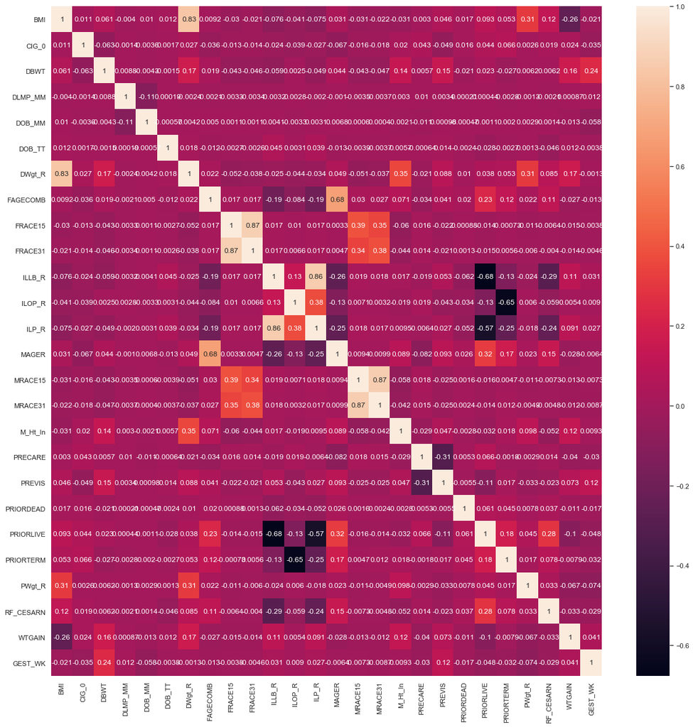

```python
#correlation analysis

plt.figure(figsize=(20, 20))
corr = df_numeric.corr()
sns.heatmap(corr, annot=True)
plt.show()
```

```python
# Identifying catergorical fields (chi-square)
df_categorical=birthdata[catcolumns]
```

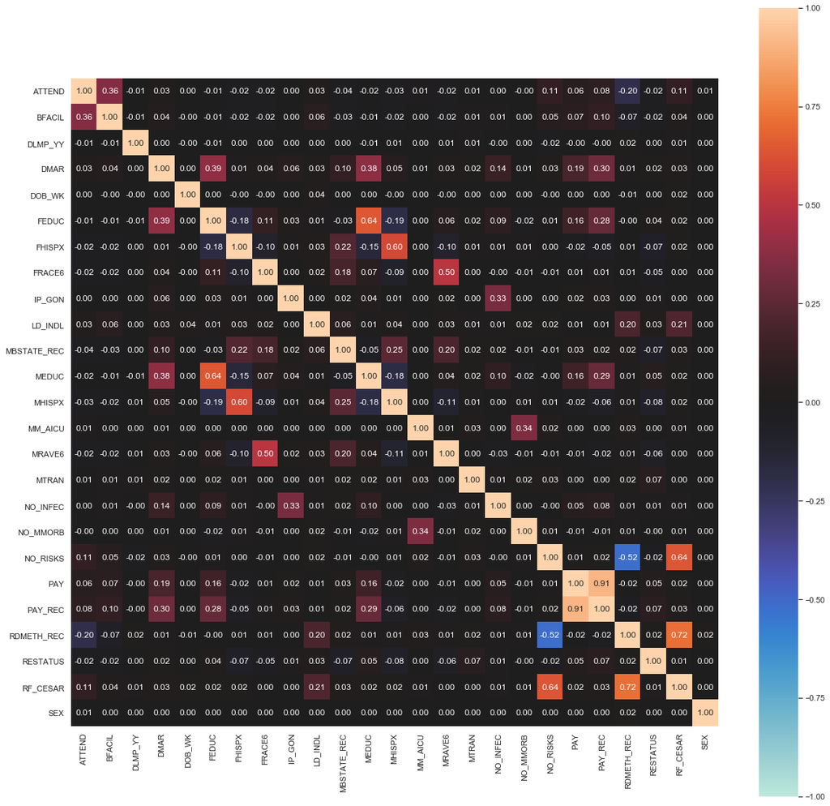

```
{'corr':                ATTEND    BFACIL   DLMP_YY      DMAR    DOB_WK     FEDUC  \
 ATTEND       1.000000  0.363186 -0.009061  0.025154  0.001206 -0.012936
 BFACIL       0.363186  1.000000 -0.007315  0.040189 -0.003544 -0.008340
 DLMP_YY     -0.009061 -0.007315  1.000000  0.004292 -0.000937 -0.008015
 DMAR         0.025154  0.040189  0.004292  1.000000  0.000425  0.394336
 DOB_WK       0.001206 -0.003544 -0.000937  0.000425  1.000000  0.001003
 FEDUC       -0.012936 -0.008340 -0.008015  0.394336  0.001003  1.000000
 FHISPX      -0.019115 -0.021238  0.003504  0.012155 -0.000902 -0.176195
 FRACE6      -0.016908 -0.018962  0.004430  0.037555 -0.000991  0.110071
 IP_GON       0.002209  0.002677  0.001059  0.056970  0.000586  0.033917
 LD_INDL      0.031147  0.064391  0.002336  0.028211  0.038016  0.007933
 MBSTATE_REC -0.037497 -0.028180  0.004358  0.103897  0.000939 -0.026881
 MEDUC       -0.015556 -0.006989 -0.006848  0.383655  0.002471  0.643818
 MHISPX      -0.025070 -0.023246  0.007125  0.054668 -0.001543 -0.187589
 MM_AICU      0.008743  0.001142  0.003438  0.005441  0.000016  0.004093
 MRAVE6      -0.019696 -0.019210  0.006021  0.033565 -0.000692  0.058720
 MTRAN        0.006573  0.007990  0.008060  0.019862  0.000235  0.018757
 NO_INFEC     0.002834  0.009226 -0.000242  0.137815  0.000932  0.089692
 NO_MMORB    -0.001458  0.002692  0.000061  0.007768  0.000238 -0.019507
 NO_RISKS     0.105505  0.054133 -0.020115  0.026893 -0.001866  0.011109
 PAY          0.062099  0.070701 -0.003656  0.194622  0.000918  0.160293
 PAY_REC      0.078391  0.104904 -0.004395  0.299712  0.001186  0.281212
 RDMETH_REC  -0.196760 -0.070298  0.015786  0.013280 -0.010495 -0.002108
 RESTATUS    -0.016691 -0.023164  0.001106  0.022457  0.000187  0.038876
 RF_CESAR     0.106224  0.036655  0.008152  0.030237  0.016792  0.019154
 SEX          0.006548  0.002849  0.001756  0.000728  0.000336  0.001939

                FHISPX    FRACE6    IP_GON   LD_INDL  MBSTATE_REC     MEDUC  \
 ATTEND      -0.019115 -0.016908  0.002209  0.031147    -0.037497 -0.015556
 BFACIL      -0.021238 -0.018962  0.002677  0.064391    -0.028180 -0.006989
 DLMP_YY      0.003504  0.004430  0.001059  0.002336     0.004358 -0.006848
 DMAR         0.012155  0.037555  0.056970  0.028211     0.103897  0.383655
 DOB_WK      -0.000902 -0.000991  0.000586  0.038016     0.000939  0.002471
 FEDUC       -0.176195  0.110071  0.033917  0.007933    -0.026881  0.643818
 FHISPX       1.000000 -0.099137  0.011630  0.031055     0.221841 -0.154930
 FRACE6      -0.099137  1.000000  0.001522  0.024628     0.181105  0.068992
 IP_GON       0.011630  0.001522  1.000000  0.003403     0.021439  0.040141
 LD_INDL      0.031055  0.024628  0.003403  1.000000     0.064141  0.008668
 MBSTATE_REC  0.221841  0.181105  0.021439  0.064141     1.000000 -0.053522
 MEDUC       -0.154930  0.068992  0.040141  0.008668    -0.053522  1.000000
```

[output cut: 80 more lines]

```
 MEDUC        0.001767
 MHISPX       0.001836
 MM_AICU      0.000000
 MRAVE6       0.000940
 MTRAN        0.002473
 NO_INFEC     0.000311
 NO_MMORB     0.003755
 NO_RISKS     0.002414
 PAY          0.000955
 PAY_REC      0.001484
 RDMETH_REC   0.017272
 RESTATUS     0.001029
 RF_CESAR     0.000000
 SEX          1.000000  ,
 'ax': <matplotlib.axes._subplots.AxesSubplot at 0x2d536205d48>}
```

```python
#Performing correlation on catergorical fields

associations(df_categorical,figsize=(20, 20))
```

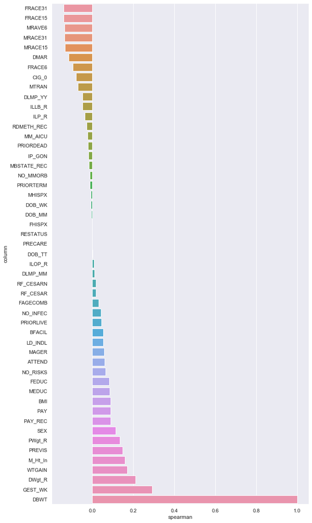

```python
# Spearman's rank correlation to visualize the co-relation with the target variable DBWT

def func_spearman(df, column):
    data = pd.DataFrame()
    data['column'] = column
    data['spearman'] = [df[f].corr(df['DBWT'], 'spearman') for f in column]
    data = data.sort_values('spearman')
    plt.figure(figsize=(10, 20))
    sns.barplot(data=data, y='column', x='spearman', orient='h')
    return
feat = birthdata.columns
func_spearman(birthdata, feat)
```

```python
# Based on spearman correlation and analyzing the features we have dropped the below columns which are least related to target variable
# and also column,that provides details about post delivery, which does not add any value addition.
birthdata = birthdata.drop(['FHISPX','RESTATUS','PRECARE','DOB_TT','ILOP_R','DLMP_MM','RF_CESARN','RF_CESAR','DOB_MM','DOB_WK','MHISPX','PRIORTERM','NO_MMORB',
                              'MBSTATE_REC','IP_GON','PRIORDEAD','MM_AICU','RDMETH_REC','ILP_R','ILLB_R','FRACE15','LD_INDL','MRACE15','MRAVE6','PWgt_R','DLMP_YY',
                              'FAGECOMB','PRIORLIVE','MTRAN','CIG_0','FRACE6','DMAR','PAY_REC','DWgt_R','ATTEND','PAY','BFACIL'],axis = 1)
birthdata.head()
```

|  | BMI | DBWT | FEDUC | FRACE31 | MAGER | MEDUC | MRACE31 | M_Ht_In | NO_INFEC | NO_RISKS | PREVIS | SEX | WTGAIN | GEST_WK |
| --- | --- | --- | --- | --- | --- | --- | --- | --- | --- | --- | --- | --- | --- | --- |
| 0 | 30.7 | 3657.0 | 3.0 | 1.0 | 30 | 6 | 1 | 66.0 | 1.0 | 1.0 | 8.0 | M | 41.0 | 36 |
| 1 | 33.3 | 3242.0 | 4.0 | 3.0 | 35 | 9 | 3 | 63.0 | 1.0 | 0.0 | 9.0 | F | 0.0 | 25 |
| 2 | 30.0 | 3470.0 | 4.0 | 1.0 | 28 | 6 | 1 | 71.0 | 1.0 | 0.0 | 17.0 | M | 58.0 | 36 |
| 3 | 23.7 | 3140.0 | 2.0 | 3.0 | 23 | 2 | 3 | 64.0 | 1.0 | 1.0 | 6.0 | F | 0.0 | 32 |
| 4 | 35.5 | 2125.0 | 3.0 | 2.0 | 37 | 4 | 1 | 66.0 | 1.0 | 1.0 | 15.0 | M | 0.0 | 25 |

```python
# Understanding the shape of the data, after dropping the columns.
birthdata.shape
```

```
(3801498, 14)
```

Prediction of birth weight has highest significance if it can be before the birth of the the baby, so that appropriate action can be taken to take corrective measure. Hence we are finalizing, features which can be available during anytime of the pregnancy

```python
# These features will be used for model building, DBWT is target varaible

birthdata.columns
```

```
Index(['BMI', 'DBWT', 'FEDUC', 'FRACE31', 'MAGER', 'MEDUC', 'MRACE31',
       'M_Ht_In', 'NO_INFEC', 'NO_RISKS', 'PREVIS', 'SEX', 'WTGAIN',
       'GEST_WK'],
      dtype='object')
```

```python
# Determine object type variable for imputation before model building
objectTypeFeature = [f for f in birthdata.columns if birthdata.dtypes[f] == 'object']
print('Object features are :',objectTypeFeature)
```

```
Object features are : ['SEX']
```

```python
birthdata=func_labelEncoder(birthdata,objectTypeFeature)
```

```python
# keeping data set in another valiable , this will be used in modeling without outlier imputation
df=birthdata
```

```python
# Binning the data for all numeric columns
def func_createBin(df, cols, no=4):
    d1 = df.copy()
    for i in cols[1:len(cols)]:
        bins = np.linspace(d1[i].min(), d1[i].max(), no)
        d1[i + "Bin"] = pd.cut(d1[i], bins, precision=1, include_lowest=True, right=True)

    return d1

binCol=birthdata.columns
df_bin=func_createBin(birthdata, binCol, no=4)

df_bin
```

|  | BMI | DBWT | FEDUC | FRACE31 | MAGER | MEDUC | MRACE31 | M_Ht_In | NO_INFEC | NO_RISKS | PREVIS | SEX | WTGAIN | GEST_WK | DBWTBin | FEDUCBin | FRACE31Bin | MAGERBin | MEDUCBin | MRACE31Bin | M_Ht_InBin | NO_INFECBin | NO_RISKSBin | PREVISBin | SEXBin | WTGAINBin | GEST_WKBin |
| --- | --- | --- | --- | --- | --- | --- | --- | --- | --- | --- | --- | --- | --- | --- | --- | --- | --- | --- | --- | --- | --- | --- | --- | --- | --- | --- | --- |
| 0 | 30.700000 | 3657.0 | 3.0 | 1.000000 | 30 | 6 | 1 | 66.000000 | 1.0 | 1.0 | 8.0 | 1 | 41.000000 | 36 | (2873.0, 5519.0] | (0.9, 3.3] | (0.9, 11.0] | (24.7, 37.3] | (3.7, 6.3] | (0.9, 11.0] | (62.0, 78.0] | (0.7, 1.0] | (0.7, 1.0] | (-0.1, 32.7] | (0.7, 1.0] | (32.7, 65.3] | (30.0, 45.0] |
| 1 | 33.300000 | 3242.0 | 4.0 | 3.000000 | 35 | 9 | 3 | 63.000000 | 1.0 | 0.0 | 9.0 | 0 | 0.000000 | 25 | (2873.0, 5519.0] | (3.3, 5.7] | (0.9, 11.0] | (24.7, 37.3] | (6.3, 9.0] | (0.9, 11.0] | (62.0, 78.0] | (0.7, 1.0] | (-0.1, 0.3] | (-0.1, 32.7] | (-0.1, 0.3] | (-0.1, 32.7] | (15.0, 30.0] |
| 2 | 30.000000 | 3470.0 | 4.0 | 1.000000 | 28 | 6 | 1 | 71.000000 | 1.0 | 0.0 | 17.0 | 1 | 58.000000 | 36 | (2873.0, 5519.0] | (3.3, 5.7] | (0.9, 11.0] | (24.7, 37.3] | (3.7, 6.3] | (0.9, 11.0] | (62.0, 78.0] | (0.7, 1.0] | (-0.1, 0.3] | (-0.1, 32.7] | (0.7, 1.0] | (32.7, 65.3] | (30.0, 45.0] |
| 3 | 23.700000 | 3140.0 | 2.0 | 3.000000 | 23 | 2 | 3 | 64.000000 | 1.0 | 1.0 | 6.0 | 0 | 0.000000 | 32 | (2873.0, 5519.0] | (0.9, 3.3] | (0.9, 11.0] | (11.9, 24.7] | (0.9, 3.7] | (0.9, 11.0] | (62.0, 78.0] | (0.7, 1.0] | (0.7, 1.0] | (-0.1, 32.7] | (-0.1, 0.3] | (-0.1, 32.7] | (30.0, 45.0] |
| 4 | 35.500000 | 2125.0 | 3.0 | 2.000000 | 37 | 4 | 1 | 66.000000 | 1.0 | 1.0 | 15.0 | 1 | 0.000000 | 25 | (226.9, 2873.0] | (0.9, 3.3] | (0.9, 11.0] | (24.7, 37.3] | (3.7, 6.3] | (0.9, 11.0] | (62.0, 78.0] | (0.7, 1.0] | (0.7, 1.0] | (-0.1, 32.7] | (0.7, 1.0] | (-0.1, 32.7] | (15.0, 30.0] |
| ... | ... | ... | ... | ... | ... | ... | ... | ... | ... | ... | ... | ... | ... | ... | ... | ... | ... | ... | ... | ... | ... | ... | ... | ... | ... | ... | ... |
| 3801529 | 26.300000 | 2140.0 | 3.0 | 1.000000 | 32 | 3 | 2 | 67.000000 | 1.0 | 0.0 | 10.0 | 1 | 47.000000 | 32 | (226.9, 2873.0] | (0.9, 3.3] | (0.9, 11.0] | (24.7, 37.3] | (0.9, 3.7] | (0.9, 11.0] | (62.0, 78.0] | (0.7, 1.0] | (-0.1, 0.3] | (-0.1, 32.7] | (0.7, 1.0] | (32.7, 65.3] | (30.0, 45.0] |
| 3801530 | 32.400000 | 3560.0 | 2.0 | 1.000000 | 23 | 2 | 1 | 65.000000 | 1.0 | 1.0 | 13.0 | 1 | 10.000000 | 36 | (2873.0, 5519.0] | (0.9, 3.3] | (0.9, 11.0] | (11.9, 24.7] | (0.9, 3.7] | (0.9, 11.0] | (62.0, 78.0] | (0.7, 1.0] | (0.7, 1.0] | (-0.1, 32.7] | (0.7, 1.0] | (-0.1, 32.7] | (30.0, 45.0] |
| 3801531 | 27.600000 | 3367.0 | 3.0 | 4.000000 | 35 | 3 | 4 | 63.000000 | 1.0 | 1.0 | 11.0 | 0 | 22.000000 | 32 | (2873.0, 5519.0] | (0.9, 3.3] | (0.9, 11.0] | (24.7, 37.3] | (0.9, 3.7] | (0.9, 11.0] | (62.0, 78.0] | (0.7, 1.0] | (0.7, 1.0] | (-0.1, 32.7] | (-0.1, 0.3] | (-0.1, 32.7] | (30.0, 45.0] |
| 3801532 | 27.167775 | 320.0 | 3.0 | 1.621382 | 36 | 9 | 1 | 64.123092 | 1.0 | 1.0 | 0.0 | 1 | 29.473329 | 20 | (226.9, 2873.0] | (0.9, 3.3] | (0.9, 11.0] | (24.7, 37.3] | (6.3, 9.0] | (0.9, 11.0] | (62.0, 78.0] | (0.7, 1.0] | (0.7, 1.0] | (-0.1, 32.7] | (0.7, 1.0] | (-0.1, 32.7] | (15.0, 30.0] |
| 3801533 | 42.100000 | 2455.0 | 3.0 | 2.000000 | 30 | 5 | 2 | 62.000000 | 1.0 | 1.0 | 8.0 | 0 | 72.000000 | 36 | (226.9, 2873.0] | (0.9, 3.3] | (0.9, 11.0] | (24.7, 37.3] | (3.7, 6.3] | (0.9, 11.0] | (46.0, 62.0] | (0.7, 1.0] | (0.7, 1.0] | (-0.1, 32.7] | (-0.1, 0.3] | (65.3, 98.0] | (30.0, 45.0] |

3801498 rows × 27 columns

```python
# perform PCA with all components to understand co-variance ratio
pca=PCA()
pca.n_components=13
pca_data=pca.fit_transform(birthdata.drop('DBWT', axis=1))
pc_var_expl = pca.explained_variance_ratio_;
var_expl=np.cumsum(pc_var_expl)
```

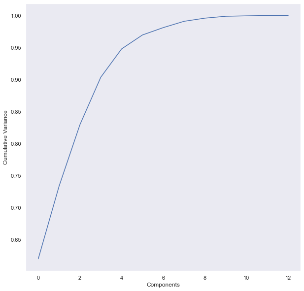

```python
#plot PCA spectrum
plt.figure(1,figsize=(10,10))
plt.clf()
plt.plot(var_expl)

plt.grid()
plt.xlabel('Components')
plt.ylabel('Cumulative Variance')
plt.show()
```

```python
birthdata.describe
```

```
<bound method NDFrame.describe of                BMI    DBWT  FEDUC   FRACE31  MAGER  MEDUC  MRACE31    M_Ht_In  \
0        30.700000  3657.0    3.0  1.000000     30      6        1  66.000000
1        33.300000  3242.0    4.0  3.000000     35      9        3  63.000000
2        30.000000  3470.0    4.0  1.000000     28      6        1  71.000000
3        23.700000  3140.0    2.0  3.000000     23      2        3  64.000000
4        35.500000  2125.0    3.0  2.000000     37      4        1  66.000000
...            ...     ...    ...       ...    ...    ...      ...        ...
3801529  26.300000  2140.0    3.0  1.000000     32      3        2  67.000000
3801530  32.400000  3560.0    2.0  1.000000     23      2        1  65.000000
3801531  27.600000  3367.0    3.0  4.000000     35      3        4  63.000000
3801532  27.167775   320.0    3.0  1.621382     36      9        1  64.123092
3801533  42.100000  2455.0    3.0  2.000000     30      5        2  62.000000

         NO_INFEC  NO_RISKS  PREVIS  SEX     WTGAIN  GEST_WK
0             1.0       1.0     8.0    1  41.000000       36
1             1.0       0.0     9.0    0   0.000000       25
2             1.0       0.0    17.0    1  58.000000       36
3             1.0       1.0     6.0    0   0.000000       32
4             1.0       1.0    15.0    1   0.000000       25
...           ...       ...     ...  ...        ...      ...
3801529       1.0       0.0    10.0    1  47.000000       32
3801530       1.0       1.0    13.0    1  10.000000       36
3801531       1.0       1.0    11.0    0  22.000000       32
3801532       1.0       1.0     0.0    1  29.473329       20
3801533       1.0       1.0     8.0    0  72.000000       36

[3801498 rows x 14 columns]>
```

# Model Building

### Model with Outliers

```python
target='DBWT'
# split the data into train and test

x = birthdata.drop(target, axis=1)
y = birthdata[target]

x_train, x_test, y_train, y_test = train_test_split(x, y, test_size=0.3,random_state=42)

scaler = StandardScaler()
x_train = scaler.fit_transform(x_train)
x_test = scaler.transform(x_test)
```

```python
# Model bulding using Linear regression on the training dataset

model = LinearRegression()
model.fit(x_train, y_train)
```

```
LinearRegression(copy_X=True, fit_intercept=True, n_jobs=None, normalize=False)
```

```python
# Testing the model using test dataset
y_pred = model.predict(x_test)
```

```python
# Perform the model evaluation on test data
def ModelEvaluation(testData, predData):
    print("Mean squared error(MSE) = %.2f" %   mean_squared_error(testData, predData))
    print("Root Mean squared error(RMSE) = %.2f" % math.sqrt(  mean_squared_error(testData, predData)))
    print('Mean Absolute Error:', metrics.mean_absolute_error(testData, predData))
    print('R squared = %.2f' % r2_score(testData, predData))

    return r2_score(testData, predData)
```

```python
modelName=[]
accuracy=[]
```

```python
# model evaluation

print("Linear Regression")

r2=ModelEvaluation(y_test,y_pred)
modelName.append("LinearRegression_withOutliers")
accuracy.append(r2)
```

```
Linear Regression
Mean squared error(MSE) = 300847.06
Root Mean squared error(RMSE) = 548.50
Mean Absolute Error: 408.7631695899493
R squared = 0.14
```

```python
# Model bulding using random forest

regressor = RandomForestRegressor(n_estimators=20, random_state=0)
regressor.fit(x_train, y_train)
```

```
RandomForestRegressor(bootstrap=True, ccp_alpha=0.0, criterion='mse',
                      max_depth=None, max_features='auto', max_leaf_nodes=None,
                      max_samples=None, min_impurity_decrease=0.0,
                      min_impurity_split=None, min_samples_leaf=1,
                      min_samples_split=2, min_weight_fraction_leaf=0.0,
                      n_estimators=20, n_jobs=None, oob_score=False,
                      random_state=0, verbose=0, warm_start=False)
```

```python
# Testing the model on test dataset
y_pred = regressor.predict(x_test)
```

```python
# Perfrom model evaluation

print("Random Forest ")

r2=ModelEvaluation(y_test,y_pred)
modelName.append("RandomForest_withOutliers")
accuracy.append(r2)
```

```
Random Forest
Mean squared error(MSE) = 250791.68
Root Mean squared error(RMSE) = 500.79
Mean Absolute Error: 384.31478649214114
R squared = 0.28
```

### Model without outliers

```python
# Removing outliers
Q1 = birthdata.quantile(0.25)
Q3 = birthdata.quantile(0.75)
IQR = Q3 - Q1

df_out = birthdata[~((birthdata < (Q1 - 1.5 * IQR)) |(birthdata > (Q3 + 1.5 * IQR))).any(axis=1)]
```

```python
df_out.shape
```

```
(1889839, 14)
```

```python
# Splitting the datset into train and test data

x = df_out.drop(target, axis=1)
y = df_out[target]

x_train, x_test, y_train, y_test = train_test_split(x, y, test_size=0.3,random_state=42)

scaler = StandardScaler()
x_train = scaler.fit_transform(x_train)
x_test = scaler.transform(x_test)
```

```python
x_test.shape
```

```
(566952, 13)
```

```python
# Model bulding using Linear regression

model = LinearRegression()
model.fit(x_train, y_train)
```

```
LinearRegression(copy_X=True, fit_intercept=True, n_jobs=None, normalize=False)
```

```python
# Testing the model
y_pred = model.predict(x_test)
```

```python
# Perform model evaluation

print("Linear Regression")

r2=ModelEvaluation(y_test,y_pred)
modelName.append("LinearRegression_withoutOutliers")
accuracy.append(r2)
```

```
Linear Regression
Mean squared error(MSE) = 177415.04
Root Mean squared error(RMSE) = 421.21
Mean Absolute Error: 332.78804504394293
R squared = 0.12
```

```python
# Model bulding using random forest
regressor = RandomForestRegressor(n_estimators=20, random_state=0)
regressor.fit(x_train, y_train)
```

```
RandomForestRegressor(bootstrap=True, ccp_alpha=0.0, criterion='mse',
                      max_depth=None, max_features='auto', max_leaf_nodes=None,
                      max_samples=None, min_impurity_decrease=0.0,
                      min_impurity_split=None, min_samples_leaf=1,
                      min_samples_split=2, min_weight_fraction_leaf=0.0,
                      n_estimators=20, n_jobs=None, oob_score=False,
                      random_state=0, verbose=0, warm_start=False)
```

```python
# Testing the model
y_pred = regressor.predict(x_test)
```

```python
# Perform model evaluation


print("Random Forest ")

r2=ModelEvaluation(y_test,y_pred)
modelName.append("RandomForest_withoutOutliers")
accuracy.append(r2)
```

```
Random Forest
Mean squared error(MSE) = 191496.89
Root Mean squared error(RMSE) = 437.60
Mean Absolute Error: 346.6139513987911
R squared = 0.05
```

### Model with PCA

```python
a = birthdata.drop(target, axis=1)
b = birthdata[target]
```

```python
a = StandardScaler().fit_transform(a)
```

```python
columns = ['p1','p2','p3','p4','p5','p6']
```

```python
# we observed from the above graph that beyond 6 components the variance has not changed much.
# Hence we have finalized to use 6 principal components.
pca = PCA(n_components=6)
principalComponents = pca.fit_transform(a)
principalDf = pd.DataFrame(data = principalComponents, columns = columns)
```

```python
principalDf.head()
```

|  | p1 | p2 | p3 | p4 | p5 | p6 |
| --- | --- | --- | --- | --- | --- | --- |
| 0 | 0.240484 | -0.576548 | -0.517962 | -0.474653 | 0.507779 | -0.737615 |
| 1 | 1.193491 | 3.219953 | 0.825730 | -1.663620 | -1.190960 | 0.656355 |
| 2 | 1.526324 | -0.333511 | -1.138766 | 0.443782 | 2.876906 | 0.523609 |
| 3 | -2.364253 | 0.154745 | 1.347585 | -0.629962 | -1.816397 | 0.234459 |
| 4 | -0.206003 | 1.951061 | -0.545832 | -0.900906 | -0.007621 | -0.804147 |

```python
x_train, x_test, y_train, y_test = train_test_split(principalDf, b, test_size=0.3,random_state=42)
```

```python
# Model bulding using Linear regression
model = LinearRegression()
model.fit(x_train, y_train)
```

```
LinearRegression(copy_X=True, fit_intercept=True, n_jobs=None, normalize=False)
```

```python
# Testing the model
y_pred = model.predict(x_test)
```

```python
# Perform model evaluation

print("Linear Regression")

r2=ModelEvaluation(y_test,y_pred)

modelName.append("LinearRegression_withPCA")
accuracy.append(r2)
```

```
Linear Regression
Mean squared error(MSE) = 311961.47
Root Mean squared error(RMSE) = 558.54
Mean Absolute Error: 417.7599535728892
R squared = 0.11
```

```python
# Model bulding using random forest
regressor = RandomForestRegressor(n_estimators=20, random_state=0)
regressor.fit(x_train, y_train)
```

```
RandomForestRegressor(bootstrap=True, ccp_alpha=0.0, criterion='mse',
                      max_depth=None, max_features='auto', max_leaf_nodes=None,
                      max_samples=None, min_impurity_decrease=0.0,
                      min_impurity_split=None, min_samples_leaf=1,
                      min_samples_split=2, min_weight_fraction_leaf=0.0,
                      n_estimators=20, n_jobs=None, oob_score=False,
                      random_state=0, verbose=0, warm_start=False)
```

```python
# Testing the model
y_pred = regressor.predict(x_test)
```

```python
# Perform model evaluation


print("Random Forest ")

r2=ModelEvaluation(y_test,y_pred)
modelName.append("RandomForest_withPCA")
accuracy.append(r2)
```

```
Random Forest
Mean squared error(MSE) = 292758.46
Root Mean squared error(RMSE) = 541.07
Mean Absolute Error: 410.9049898417811
R squared = 0.16
```

### Model with outlier imputation

```python
#imputing outliers with median

for col_name in df.select_dtypes(include=np.number).columns[:]:
    print(col_name)
    q1 = df[col_name].quantile(0.25)
    q3 = df[col_name].quantile(0.75)
    iqr = q3 - q1

    low = q1-1.5*iqr
    high = q3+1.5*iqr
    print("Change the outliers with median ",df[col_name].median())
    df.loc[(df[col_name] < low) | (df[col_name] > high), col_name] = df[col_name].median()
```

```
BMI
Change the outliers with median  25.8
DBWT
Change the outliers with median  3300.0
FEDUC
Change the outliers with median  3.0
FRACE31
Change the outliers with median  1.0
MAGER
Change the outliers with median  29.0
MEDUC
Change the outliers with median  4.0
MRACE31
Change the outliers with median  1.0
M_Ht_In
Change the outliers with median  64.0
NO_INFEC
Change the outliers with median  1.0
NO_RISKS
Change the outliers with median  1.0
PREVIS
Change the outliers with median  11.290498456237948
SEX
Change the outliers with median  1.0
WTGAIN
Change the outliers with median  29.473329491821136
GEST_WK
Change the outliers with median  36.0
```

```python
x = df.drop(target, axis=1)
y = df[target]

x_train, x_test, y_train, y_test = train_test_split(x, y, test_size=0.3,random_state=42)

scaler = StandardScaler()
x_train = scaler.fit_transform(x_train)
x_test = scaler.transform(x_test)
```

```python
# Model bulding using Linear regression on the training dataset

model = LinearRegression()
model.fit(x_train, y_train)
```

```
LinearRegression(copy_X=True, fit_intercept=True, n_jobs=None, normalize=False)
```

```python
# Testing the model using test dataset
y_pred = model.predict(x_test)
```

```python
# model evaluation

print("Linear Regression")

r2=ModelEvaluation(y_test,y_pred)
modelName.append("LinearRegression_withOutlierImput")
accuracy.append(r2)
```

```
Linear Regression
Mean squared error(MSE) = 205350.11
Root Mean squared error(RMSE) = 453.16
Mean Absolute Error: 355.17777848247505
R squared = 0.09
```

```python
# Model bulding using random forest

regressor = RandomForestRegressor(n_estimators=20, random_state=0)
regressor.fit(x_train, y_train)
```

```
RandomForestRegressor(bootstrap=True, ccp_alpha=0.0, criterion='mse',
                      max_depth=None, max_features='auto', max_leaf_nodes=None,
                      max_samples=None, min_impurity_decrease=0.0,
                      min_impurity_split=None, min_samples_leaf=1,
                      min_samples_split=2, min_weight_fraction_leaf=0.0,
                      n_estimators=20, n_jobs=None, oob_score=False,
                      random_state=0, verbose=0, warm_start=False)
```

```python
# Testing the model on test dataset
y_pred = regressor.predict(x_test)
```

```python
# Perfrom model evaluation

print("Random Forest ")

r2=ModelEvaluation(y_test,y_pred)
modelName.append("RandomForest_withOutlierImput")
accuracy.append(r2)
```

```
Random Forest
Mean squared error(MSE) = 219738.94
Root Mean squared error(RMSE) = 468.76
Mean Absolute Error: 369.1926769744033
R squared = 0.03
```

### Model performance comparison

```python
result = pd.DataFrame(list(zip(modelName, accuracy)))
```

```python
result.columns =['Model', 'R squared']
print(result)
```

```
                               Model  R squared
0      LinearRegression_withOutliers   0.139148
1          RandomForest_withOutliers   0.282377
2   LinearRegression_withoutOutliers   0.116135
3       RandomForest_withoutOutliers   0.045980
4           LinearRegression_withPCA   0.107345
5               RandomForest_withPCA   0.162293
6  LinearRegression_withOutlierImput   0.094055
7      RandomForest_withOutlierImput   0.030576
```

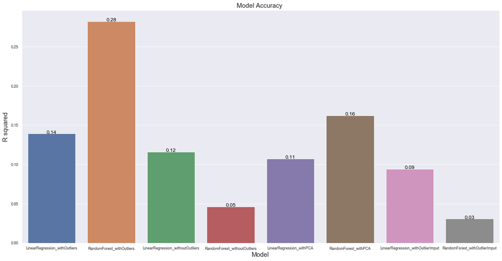

```python
plt.figure(figsize=(20, 10))
plt.title('Model Accuracy ')
sns.set_context("paper", rc={"font.size":12,"axes.titlesize":20,"axes.labelsize":15})
sn=sns.barplot(x="Model", y="R squared", data=result)

for index, row in result.iterrows():
    sn.text(row.name,row['R squared'], round(row['R squared'],2), color='black', ha="center")
```

From the above graph we can state that a Model built using Random Forest using a dataset with outliers has the highest accuracy, with an R2 value of .28, Hence we suggest this is the best model among all the various models we have tried so far

```python
#End
```